# Predicting Excessive Enforcement Patterns in Police Behavior After Vehicles Stops in New York

EDA and Feature Engineering - 2 Wheels Vehicles

Gianmaria Pizzo

These `.Rmd` files represent the project submission for the course [Statistical Inference and Learning](https://www.unive.it/data/course/521944) by Professor [Cristiano Varin](https://www.unive.it/data/people/5592728) at [Ca’ Foscari University of Venice](https://www.unive.it/) for the year 2025/2026.

# Problem Statement

## Goal of this rmarkdown file - TODO

This notebook serves as the primary Exploratory Data Analysis (EDA) and (final) Feature Engineering phase for the project.

Our specific focus is narrowed to **2-Wheeled Vehicles** (including e-bikes, motorcycles, and mopeds), a segment of NYC traffic that has seen a 2.5-fold increase in stop volume between 2023 and 2025 (which will be later shown). The goal is to identify the latent features that characterize two rare but critical police actions: **Arrests** and **Vehicle Checkpoints**.

We approach the dataset through three methodological phases to ensure a robust base for modeling:

1. **Univariate Analysis: Feature Integrity and Outlier Detection**. We begin by scrutinizing individual predictors to understand their distributions and handle data quality issues. This includes addressing the extreme class imbalance and filtering outliers.
2. **Bivariate Analysis: Predictive Signal and Initial Associations**. We evaluate the relationship between potential predictors and our binary targets (`arrested` and `veh_checkpoint`). Given the categorical nature of our data, we utilize **Cramer’s V** as a measure of effect size to rank feature importance, moving beyond the hypersensitivity of p-values in a large-sample environment.
3. **Multivariate Analysis: Interaction and Collinearity Resolution**. Finally, we explore complex interactions. This stage is critical for addressing multicollinearity early on, ensuring that redundant predictors do not inflate the estimates of our final models.

## Key Objectives - TODO

Throughout this exploration, we remain vigilant for: * **Spatial Drift:** Understanding if enforcement intensity follows traffic volume or neighborhood-specific mandates. * **Seasonal Amplification:** Analyzing how the “Hot Season” (April–October) structurally alters the enforcement landscape. * **Informative Missingness:** Investigating whether “Unknown” labels in demographics like age or ethnicity correlate with higher arrest probabilities.

By the conclusion of this notebook, we will have transformed raw observational data into a refined, engineered feature set.

## Important Note

We previously stated that we restricted the data to private vehicles. However, it is not possible for us to evaluate whether some of the vehicles aggregated here are used for delivery businesses, even though they are privately owned. In fact, the dataset does not take into account this aspect and we do not have enough info to provide a distinction. Therefore, the only comment we can make about this is that, they mostly operate during 17-22pm, and could contribute to an increased total volume of stops.

# Environment

The first to do, is to build a reproducible environment for our project.

```r
requirements=c(
  "remotes", "summarytools", "forcats", "scales", "purrr",
  "stringr", "plyr", "dbplyr", "dplyr", "dtplyr", "tidyr", "tidyselect",
  "timeDate", "timechange", "tzdb", "hms", "readr", "tigris", "lsr", "corrplot",
  "lubridate", "prettyunits", "RColorBrewer", "viridis", "rcartocolor", "ggbeeswarm", "emmeans",
  "sf", "plotly", "ggplot2", "ggmap", "ggdensity", "UpSetR", "patchwork"
)
```

Note that some of the packages may not be used, but to avoid any error related to dependencies, we are going to keep all of these libraries. Now, the loading of all packages should be immediate.

## Plot Functions

Here we add the plot functions to make some kinds of visualizations reproducible.

```r
# ==============================================================================
# 1. Plots for Univariate Analysis
# ==============================================================================
#' @title Plot Binary Bar Chart
#'
#' @description Creates a simple bar chart counting the occurrences of a binary feature,
#' with labels showing both the count and the percentage.
#'
#' @param DF The input dataframe.
#' @param FEATURE The binary column to plot (unquoted).
#' @param OPTION_0 The text label for the "0" or "FALSE" category.
#' @param OPTION_1 The text label for the "1" or "TRUE" category.
#' @param X_LABEL Label for the X axis.
#' @param Y_LABEL Label for the Y axis.
#' @param TITLE Main title of the plot.
#' @param pad Numeric padding for the top of the Y axis to fit text labels.
#' @param text_vjust Vertical adjustment for the text labels on top of bars.
#'
#' @return A ggplot2 object.
plot_binary_bar <- function(DF, FEATURE, OPTION_0, OPTION_1, X_LABEL, Y_LABEL, TITLE, pad = 0.15, text_vjust = -0.3) {

  # Standardize the binary feature and calculate percentages
  df_sum <- DF %>%
    mutate(
      .raw  = {{ FEATURE }},
      .feat = dplyr::case_when(
        as.character(.raw) %in% c("1","TRUE","true")  ~ 1L,
        as.character(.raw) %in% c("0","FALSE","false") ~ 0L,
        TRUE ~ NA_integer_
      )
    ) %>%
    filter(!is.na(.feat)) %>%
    count(.feat, name = "n") %>%
    mutate(
      .lab = factor(.feat, levels = c(0, 1), labels = c(OPTION_0, OPTION_1)),
      # NEW: Calculate percentage and create combined label
      pct = n / sum(n),
      label_text = paste0(scales::comma(n), "\n(", scales::percent(pct, accuracy = 0.1), ")")
    )

  # Get the maximum bar height
  ymax <- max(df_sum$n, na.rm = TRUE)

  # Build the ggplot
  ggplot(df_sum, aes(x = .lab, y = n, fill = .lab)) +
    geom_col(width = 0.8, show.legend = FALSE) +
    # Updated to use label_text
    geom_text(aes(label = label_text), vjust = text_vjust, lineheight = 0.8) +
    # Expand the Y axis slightly to accommodate the taller multi-line labels
    scale_y_continuous(limits = c(0, ymax * (1 + pad)),
                       expand = expansion(mult = c(0, 0.02))) +
    coord_cartesian(clip = "off") +
    theme_minimal() +
    theme(
      panel.grid.major.x = element_blank(),
      plot.margin = margin(t = 20, r = 5.5, b = 5.5, l = 5.5)
    ) +
    scale_fill_viridis_d(option = "mako", begin = 0.3, end = 0.8) +
    labs(x = X_LABEL, y = Y_LABEL, title = TITLE)
}


# FIXME: Make title and subtitle like {r count-stops-by-year}

#' @title Plot Univariate Bar Chart (Categorical)
#'
#' @description Creates a bar chart counting the occurrences of a categorical feature with 2+ classes.
#' Allows dynamic ordering (by frequency or original/alphabetical order).
#'
#' @param DF The input dataframe.
#' @param FEATURE The categorical column to analyze (unquoted).
#' @param X_LABEL Label for the X axis.
#' @param Y_LABEL Label for the Y axis (default is "Count").
#' @param TITLE Main title of the plot.
#' @param SUBTITLE Subtitle of the plot.
#' @param top_n Optional integer; if set, keeps only the top N most frequent categories.
#' @param order_by Method to order the X axis: "freq" (descending count) or "none" (alphabetical/original).
#' @param pad Numeric padding for the top of the Y axis to fit text labels.
#' @param text_vjust Vertical adjustment for the text labels on top of bars.
#'
#' @return A ggplot2 object.
plot_univariate_cat <- function(DF, FEATURE, X_LABEL, Y_LABEL = "Count", TITLE, SUBTITLE, top_n = NULL, order_by = c("freq", "none"), pad = 0.12, text_vjust = -0.35) {

  order_by <- match.arg(order_by)

  # Compute counts
  df_sum <- DF %>%
    filter(!is.na({{ FEATURE }})) %>%
    count({{ FEATURE }}, name = "n")

  # Filter top n results
  if (!is.null(top_n)) {
    df_sum <- df_sum %>% slice_max(order_by = n, n = top_n)
  }

  # X axis order (either frequency or std)
  cat_levels <- switch(
    order_by,
    freq = df_sum %>% arrange(desc(n)) %>% pull({{ FEATURE }}),
    none = sort(unique(df_sum %>% pull({{ FEATURE }})))
  )

  # Apply sorting
  df_sum <- df_sum %>%
    mutate(.feat_f = factor(as.character({{ FEATURE }}), levels = as.character(cat_levels)))

  # Max height for dynamic padding
  ymax <- max(df_sum$n, na.rm = TRUE)

  # Construct plot
  ggplot(df_sum, aes(x = .feat_f, y = n, fill = .feat_f)) +
    geom_col(width = 0.8, show.legend = FALSE) +
    geom_text(aes(label = scales::comma(n)), vjust = text_vjust, size = 3) +
    scale_y_continuous(limits = c(0, ymax * (1 + pad)),
                       expand = expansion(mult = c(0, 0.02))) +
    coord_cartesian(clip = "off") +
    theme_minimal() +
    theme(
      plot.title = element_text(size = 14),
      plot.subtitle = element_text(size = 10, color = "grey50"),
      axis.text.x = element_text(angle = 45, hjust = 1),
      panel.grid.major.x = element_blank(),
      plot.margin = margin(t = 10, r = 5.5, b = 5.5, l = 5.5)) +
    scale_fill_viridis_d(option = "mako", begin = 0.3, end = 0.8) +
    labs(x = X_LABEL, y = Y_LABEL, title = TITLE, subtitle = SUBTITLE)
}
```

```r
# ==============================================================================
# 2. Plots for Bivariate Analysis
# ==============================================================================

#' @title Calculate Cramer's V
#'
#' @description Calculates the Cramer's V measure of association between two
#' categorical vectors. Returns a value between 0 (no association) and 1 (perfect association).
#'
#' @param x First categorical vector.
#' @param y Second categorical vector.
#'
#' @return A numeric value representing Cramer's V.
cramer_v <- function(x, y) {
  # Contingency Table
  tbl <- table(x, y)

  # Execute Chi2 Test
  chi2 <- suppressWarnings(chisq.test(tbl, correct = FALSE)$statistic)

  # Compute dim and min value
  n <- sum(tbl)
  min_dim <- min(nrow(tbl) - 1, ncol(tbl) - 1)

  # Avoid math error for 1 categ
  if(min_dim == 0) return(0)

  # Cramer's formula
  v <- sqrt(chi2 / (n * min_dim))
  return(as.numeric(v))
}

# ==============================================================================
# Categorical "Correlation" Heatmap - Association Matrix based on Cramer's V
# ==============================================================================

#' @title Plot Categorical Correlation Matrix (Cramer's V)
#'
#' @description Creates a correlation-like heatmap for multiple categorical variables
#' using Cramer's V. Answers "How much do these categorical features overlap with each other?"
#'
#' @param DF The input dataframe.
#' @param FEATURES A character vector containing the names of the categorical columns to compare.
#' @param TITLE Main title of the plot.
#'
#' @return A ggplot2 object.
plot_categorical_correlation <- function(DF, FEATURES, TITLE = "Association Matrix for Categorical Predictors (Cramer's V)") {

  # Select columns and drop NAs
  df_sub <- DF %>%
    select(all_of(FEATURES)) %>%
    drop_na()

  n_vars <- ncol(df_sub)

  # Initialize matrix and set main diag to 1s
  mat <- matrix(1, nrow = n_vars, ncol = n_vars)
  rownames(mat) <- colnames(df_sub)
  colnames(mat) <- colnames(df_sub)

  # FIXME: Just do upper/lower part of matrix
  # Compute Cramer's V for each possible pair
  for(i in 1:(n_vars - 1)) {
    for(j in (i + 1):n_vars) {
      v <- cramer_v(df_sub[[i]], df_sub[[j]])
      # Symmetric
      mat[i, j] <- v
      mat[j, i] <- v
    }
  }

  # Make matrix compatible with ggplot2
  mat_long <- as.data.frame(as.table(mat))
  colnames(mat_long) <- c("Var1", "Var2", "CramerV")

  # Create heatmap
  ggplot(mat_long, aes(x = Var1, y = Var2, fill = CramerV)) +
    geom_tile(color = "white", width = 1, height = 1) +
    # Rounding
    geom_text(aes(label = round(CramerV, 2)), size = 4) +
    # Setting colors
    scale_fill_gradient(low = "whitesmoke", high = "steelblue", limits = c(0, 1), name = "Cramer's V") +
    labs(title = TITLE, x = "", y = "") +
    theme_minimal() +
    theme(
      axis.text.x = element_text(angle = 45, hjust = 1, size = 10),
      axis.text.y = element_text(size = 10),
      panel.grid = element_blank()
    )
}

# ==============================================================================
# Plotting of Targets' Rate Against Categorical Predictors
# ==============================================================================

# FIXME: Percentage shown in the wrong place.

#' @title Plot Target Ratio by Category
#'
#' @description Creates a bivariate bar chart showing the relationship between a binary
#' TARGET and a single categorical variable (CAT). It supports two visual styles:
#' a 100% stacked bar chart ("stack") or a simple bar chart showing the rate of the target ("rate").
#'
#' @param DF The input dataframe.
#' @param TARGET The binary column to analyze (unquoted). It will be standardized to 0/1.
#' @param CAT The categorical column for the X axis (unquoted).
#' @param x_title Label for the X axis.
#' @param y_title Label for the Y axis.
#' @param title Main title of the plot.
#' @param target_labels A character vector of length 2 defining the labels for 0 and 1 (e.g., c("Not escalated", "Escalated")).
#' @param style The visual style of the plot: "stack" (100% stacked bars) or "rate" (single bar for target = 1).
#' @param order_by Method to order the X axis categories: by "rate" (ascending target rate), "freq" (ascending frequency), or "none" (alphabetical/original).
#' @param percent_accuracy Accuracy for the percent labels (e.g., 0.1 for one decimal place).
#' @param colors A character vector of length 2 defining the hex color codes for the 0 and 1 categories respectively.
#'
#' @return A ggplot2 object.
ratio_by_cat <- function(DF, TARGET, CAT, x_title, y_title, title,
                         target_labels = c("Not escalated", "Escalated"),
                         style = c("stack", "rate"),
                         order_by = c("rate", "freq", "none"),
                         percent_accuracy = 0.1,
                         colors = c("grey80", "steelblue"),
                         legend_title = "Legend",
                         subtitle = NULL,
                         label_vjust = 0.5) {

  # Validate arguments
  style    <- match.arg(style)
  order_by <- match.arg(order_by)

  # Standardize target and extract the category
  dat <- DF %>%
    mutate(
      .t_raw = {{ TARGET }},
      .t = case_when(
        as.character(.t_raw) %in% c("1","TRUE","true") ~ 1L,
        as.character(.t_raw) %in% c("0","FALSE","false") ~ 0L,
        TRUE ~ NA_integer_
      ),
      .cat = {{ CAT }}
    ) %>%
    filter(!is.na(.t), !is.na(.cat))

  # Compute rates and frequencies
  rates <- dat %>%
    group_by(.cat) %>%
    summarise(total = n(), rate = mean(.t == 1), .groups = "drop")

  # Determine ordering
  cat_levels <- switch(
    order_by,
    rate = rates %>% arrange(rate) %>% pull(.cat),
    freq = rates %>% arrange(total) %>% pull(.cat),
    none = unique(dat$.cat)
  )

  # Build the plot based on style
  if (style == "stack") {
    stack <- dat %>%
      count(.cat, .t, name = "n") %>%
      group_by(.cat) %>%
      mutate(ratio = n/sum(n)) %>%
      ungroup() %>%
      mutate(
        .cat_f = factor(as.character(.cat), levels = as.character(cat_levels)),
        .t_f = factor(.t, levels = c(0,1), labels = target_labels)
      )

    ggplot(stack, aes(x = .cat_f, y = ratio, fill = .t_f)) +
      geom_col(position = "fill") +
      # CHANGED: Showing ONLY the percentage
      geom_text(
        aes(label = scales::percent(ratio, accuracy = percent_accuracy)),
        position = position_fill(vjust = label_vjust),
        size = 3
      ) +
      scale_y_continuous(labels = scales::percent) +
      scale_fill_manual(values = setNames(colors, target_labels)) +
      labs(x = x_title, y = y_title, fill = legend_title, title = title, subtitle = subtitle) +
      theme_minimal() +
      theme(
        axis.text.x = element_text(angle = 45, hjust = 1),
        panel.grid = element_blank(),
        plot.subtitle = element_text(color = "grey50")
      )

  } else {
    # Rate style
    rates_data <- rates %>%
      mutate(.cat_f = factor(as.character(.cat), levels = as.character(cat_levels)))

    ggplot(rates_data, aes(x = .cat_f, y = rate)) +
      geom_col(width = 0.8, fill = colors[2]) +
      geom_text(
        aes(label = scales::percent(rate, accuracy = percent_accuracy)),
        vjust = -0.35, size = 3
      ) +
      scale_y_continuous(labels = scales::percent, expand = expansion(mult = c(0, 0.12))) +
      coord_cartesian(clip = "off") +
      labs(x = x_title, y = y_title, title = title, subtitle = subtitle) +
      theme_minimal() +
      theme(
        axis.text.x = element_text(angle = 45, hjust = 1),
        panel.grid = element_blank(),
        plot.subtitle = element_text(color = "grey50")
      )
  }
}
```

```r
# ==============================================================================
# 3. Plots for Multivariate Analysis
# ==============================================================================

#' @title Heatmap of Target Rate (Categorical Y vs Numeric X)
#'
#' @description Plots a heatmap showing the rate of a binary TARGET across a categorical
#' Y variable and a numeric (or factor) X variable.
#'
#' @param DF The input dataframe.
#' @param TARGET The binary column to calculate the rate for (unquoted).
#' @param Y Categorical variable for the Y axis.
#' @param X Numeric or categorical variable for the X axis.
#' @param X_TITLE Label for the X axis.
#' @param Y_TITLE Label for the Y axis.
#' @param TITLE Main title of the plot.
#' @param min_n Minimum number of observations required to show a tile.
#' @param drop_na Boolean; if TRUE, rows with NA in X or Y are removed.
#' @param x_as_factor Boolean; if TRUE, forces the X variable to be treated as a categorical factor.
#'
#' @return A ggplot2 object.
heat_target_yx <- function(DF, TARGET, Y, X, X_TITLE, Y_TITLE, TITLE, min_n = 0, drop_na = TRUE, x_as_factor = FALSE) {
  # Standardize the binary target
  dat <- DF %>%
    mutate(
      .target_raw = {{ TARGET }},
      .target_bin = dplyr::case_when(
        as.character(.target_raw) %in% c("1", "TRUE", "true")  ~ 1L,
        as.character(.target_raw) %in% c("0", "FALSE", "false") ~ 0L,
        TRUE ~ NA_integer_
      )
    )

  # Filter NAs
  if (drop_na) {
    dat <- dat %>% filter(!is.na({{Y}}), !is.na({{X}}), !is.na(.target_bin))
  } else {
    dat <- dat %>% filter(!is.na(.target_bin))
  }

  # Incrementally sort Y axis based on the mean ratio of the target
  y_order <- dat %>%
    group_by({{Y}}) %>%
    summarise(rate = mean(.target_bin == 1, na.rm = TRUE), .groups = "drop") %>%
    arrange(rate) %>%
    pull({{Y}})

  # Compute the target rate for each combination of Y x X
  grid <- dat %>%
    group_by({{Y}}, {{X}}) %>%
    summarise(
      rate = mean(.target_bin == 1, na.rm = TRUE),
      n = n(), .groups = "drop"
    ) %>%
    mutate(
      .y = factor(as.character({{Y}}), levels = as.character(y_order)),
      .x = if (x_as_factor) factor({{X}}) else {{X}},
      # Hide cells that do not reach the minimum amount of observations
      rate_plot = ifelse(n >= min_n, rate, NA_real_)
    )

  # Build ggplot heatmap
  ggplot(grid, aes(.x, .y, fill = rate_plot)) +
    geom_tile(width = 1, height = 0.9) +
    scale_fill_viridis_c(labels = scales::percent, na.value = "grey90", name = "Rate") +
    labs(x = X_TITLE, y = Y_TITLE, title = TITLE) +
    theme_minimal() +
    theme(panel.grid = element_blank())
}


#' @title Heatmap of Target Rate (Categorical Y vs Categorical X)
#'
#' @description Plots a heatmap showing the rate of a binary TARGET across two categorical
#' variables (Y and X). Allows dynamic ordering and shading based on sample size.
#'
#' @param DF The input dataframe.
#' @param TARGET The binary column to calculate the rate for (unquoted).
#' @param Y Categorical variable for the Y axis.
#' @param X Categorical variable for the X axis.
#' @param X_TITLE Label for the X axis.
#' @param Y_TITLE Label for the Y axis.
#' @param TITLE Main title of the plot.
#' @param min_n Minimum number of observations required to show a tile (filters noise).
#' @param order_y_by Method to order the Y axis: by 'rate', 'freq' (frequency), or 'none'.
#' @param order_x_by Method to order the X axis: by 'rate', 'freq' (frequency), or 'none'.
#' @param alpha_by_n Boolean; if TRUE, shades tiles by count using alpha (transparency).
#'
#' @return A ggplot2 object.
heat_target_catcat <- function(DF, TARGET, Y, X, X_TITLE, Y_TITLE, TITLE, min_n = 0, order_y_by = c("rate","freq","none"), order_x_by = c("rate","freq","none"), alpha_by_n = FALSE ) {
  order_y_by <- match.arg(order_y_by)
  order_x_by <- match.arg(order_x_by)

  # Standardize target
  dat <- DF %>%
    mutate(
      .target_raw = {{ TARGET }},
      .target_bin = dplyr::case_when(
        as.character(.target_raw) %in% c("1", "TRUE", "true")  ~ 1L,
        as.character(.target_raw) %in% c("0", "FALSE", "false") ~ 0L,
        TRUE ~ NA_integer_
      )
    ) %>%
    # Filter NAs
    filter(!is.na({{Y}}), !is.na({{X}}), !is.na(.target_bin))

  # Compute stats to determine the Y axis order
  y_stats <- dat %>%
    group_by({{Y}}) %>%
    summarise(
      rate = mean(.target_bin == 1, na.rm = TRUE),
      n = n(), .groups = "drop"
    )

  # Compute stats to determine the X axis order
  x_stats <- dat %>%
    group_by({{X}}) %>%
    summarise(
      rate = mean(.target_bin == 1, na.rm = TRUE),
      n = n(), .groups = "drop"
    )

  # Apply chosen "order by" to Y
  y_levels <- switch(
    order_y_by,
    rate = y_stats %>% arrange(rate) %>% pull({{Y}}),
    freq = y_stats %>% arrange(n) %>% pull({{Y}}),
    none = unique(dat %>% pull({{Y}}))
  )

  # Apply chosen "order by" to X
  x_levels <- switch(
    order_x_by,
    rate = x_stats %>% arrange(rate) %>% pull({{X}}),
    freq = x_stats %>% arrange(n) %>% pull({{X}}),
    none = unique(dat %>% pull({{X}}))
  )

  # Compute the cell's target rate and counts for each combination of Y x X
  grid <- dat %>%
    group_by({{Y}}, {{X}}) %>%
    summarise(
      rate = mean(.target_bin == 1, na.rm = TRUE),
      n = n(), .groups = "drop"
    ) %>%
    mutate(
      .y = factor(as.character({{Y}}), levels = as.character(y_levels)),
      .x = factor(as.character({{X}}), levels = as.character(x_levels)),
      rate_plot = ifelse(n >= min_n, rate, NA_real_)
    )

  # Build the plot
  p <- ggplot(grid, aes(.x, .y)) +
    labs(x = X_TITLE, y = Y_TITLE, title = TITLE) +
    theme_minimal() +
    theme(panel.grid = element_blank()) +
    # Use scales for displaying rates
    scale_fill_viridis_c(labels = scales::percent, na.value = "grey90", name = "Rate")

  if (alpha_by_n) {
    p <- p +
      geom_tile(aes(fill = rate_plot, alpha = n), width = 0.95, height = 0.95) +
      scale_alpha_continuous(range = c(0.25, 1), name = "Stops")
  } else {
    p <- p +
      geom_tile(aes(fill = rate_plot), width = 0.95, height = 0.95)
  }

  p
}


#' @title Stacked Ratio Bars Split by a Third Variable
#'
#' @description Creates a faceted 100% stacked bar chart. This is highly effective
#' for visualizing how the rate of a binary TARGET changes across a primary category (CAT),
#' while simultaneously splitting the data by a third variable (SPLIT) to create side-by-side plots.
#'
#' @param DF The input dataframe.
#' @param TARGET The binary column to analyze (unquoted). It will be standardized to 0/1.
#' @param CAT The main categorical variable for the X axis (unquoted).
#' @param SPLIT The categorical variable used to split/facet the plots (unquoted).
#' @param x_title Label for the X axis.
#' @param y_title Label for the Y axis.
#' @param title Main title of the entire plot.
#' @param target_labels Character vector of length 2 defining labels for the binary outcomes (e.g., c("Not escalated", "Escalated")).
#' @param split_labels Optional character vector to provide custom titles for the split panels (facets).
#' @param palette A character string specifying an RColorBrewer palette name (e.g., "Paired", "Set1").
#' @param percent_accuracy Accuracy for the percentage labels (e.g., 0.1 for one decimal place).
#'
#' @return A ggplot2 object.
ratio_by_cat_split <- function(DF, TARGET, CAT, SPLIT, x_title, y_title, title, target_labels = c("Not escalated", "Escalated"), split_labels = NULL, palette = "Paired", percent_accuracy = 0.1){
  # Standardize target
  dat <- DF %>%
    mutate(
      .target_raw = {{ TARGET }},
      # Conversion to 0/1
      .target_bin = case_when(
        as.character(.target_raw) %in% c("1", "TRUE", "true") ~ 1L,
        as.character(.target_raw) %in% c("0", "FALSE", "false") ~ 0L,
        TRUE ~ NA_integer_
      ),
      .cat = {{ CAT }},
      .split = {{ SPLIT }}
    ) %>%
    # Filter NAs
    filter(!is.na(.cat), !is.na(.split), !is.na(.target_bin))

  # Order the main categories based on the overall target rate (from lowest to highest)
  cat_order <- dat %>%
    group_by(.cat) %>%
    summarise(
      rate = mean(.target_bin == 1),
      .groups = "drop"
    ) %>%
    arrange(rate) %>%
    pull(.cat)

  # Tidy labels by converting character to factors
  dat <- dat %>%
    mutate(
      # Apply the order to X axis
      .cat = factor(as.character(.cat), levels = as.character(cat_order)),
      # Apply custom labels to the target
      .target_f = factor(.target_bin, levels = c(0, 1), labels = target_labels),
      # Format the split variable
      .split_f = {
        lv <- unique(as.character(.split))
        # If custom split labels are provided and the length matches, use them
        if (!is.null(split_labels) && length(split_labels) == length(lv))
          factor(as.character(.split), levels = lv, labels = split_labels)
        else factor(as.character(.split), levels = lv)
      }
    )

  # Compute rates
  plot_df <- dat %>%
    count(.split_f, .cat, .target_f, name = "n") %>%
    group_by(.split_f, .cat) %>%
    mutate(ratio = n/sum(n)) %>%
    ungroup()

  # Build plot
  ggplot(plot_df, aes(x = .cat, y = ratio, fill = .target_f)) +
    # Stacks the bars to exactly 100%
    geom_col(position = "fill") +
    # Add ratio text labels
    geom_text(
      aes(label = percent(ratio, accuracy = percent_accuracy)),
      position = position_fill(vjust = 0.5),
      size = 3
    ) +
    # Format Y axis as percentages and make continuous
    scale_y_continuous(labels = percent) +
    # Use a clean palette for the target categories
    scale_fill_brewer(palette = palette, name = rlang::as_name(rlang::enquo(TARGET))) +
    labs(x = x_title, y = y_title, title = title) +
    # Split the plot into separate panels based on the .split_f variable
    facet_wrap(~ .split_f, nrow = 1) +
    theme_minimal() +
    theme(axis.text.x = element_text(angle = 45, hjust = 1),
          panel.grid = element_blank())
}
```

```r
#' @title Plot Temporal Trend of Target Rate
#'
#' @description Creates a scatter plot with a LOESS smoothing curve to visualize
#' how the rate of a target event changes over a continuous temporal variable (e.g., date, day of year).
#' The size of the points represents the volume of stops.
#'
#' @param DF The input dataframe.
#' @param TARGET The binary column to analyze (unquoted).
#' @param TIME_VAR The continuous time variable for the X axis (e.g., date, doy).
#' @param x_title Label for the X axis.
#' @param y_title Label for the Y axis.
#' @param title Main title of the plot.
plot_temporal_trend <- function(DF, TARGET, TIME_VAR, x_title = "Tempo", y_title = "Tasso", title = "Trend Temporale") {

  # Step 1: Standardizzare il target a 0/1
  dat <- DF %>%
    mutate(
      .target_raw = {{ TARGET }},
      .target_bin = case_when(
        as.character(.target_raw) %in% c("1","TRUE","true", "Yes")  ~ 1L,
        as.character(.target_raw) %in% c("0","FALSE","false", "No") ~ 0L,
        TRUE ~ NA_integer_
      ),
      .time = {{ TIME_VAR }}
    ) %>%
    filter(!is.na(.target_bin), !is.na(.time))

  # Step 2: Calcolare il tasso e il volume per ogni unità di tempo
  plot_df <- dat %>%
    group_by(.time) %>%
    summarise(
      rate = mean(.target_bin == 1, na.rm = TRUE),
      n = n(),
      .groups = "drop"
    )

  # Step 3: Costruire il grafico
  ggplot(plot_df, aes(x = .time, y = rate)) +
    # Punti proporzionali al numero di stop per capire la robustezza del dato
    geom_point(aes(size = n), alpha = 0.5, color = "steelblue") +
    # Linea di tendenza morbida per evidenziare il trend generale ignorando il rumore
    geom_smooth(se = FALSE, method = "loess", span = 0.3, color = "firebrick", size = 1.2) +
    scale_y_continuous(labels = scales::percent) +
    labs(x = x_title, y = y_title, size = "N. di Stop", title = title) +
    theme_minimal() +
    theme(panel.grid.minor = element_blank())
}

#' @title Plot Cyclic Time Heatmap
#'
#' @description Creates a heatmap specifically designed for cyclic time variables
#' (like Hour of Day vs Day of Week) to spot temporal hotspots.
#'
#' @param DF The input dataframe.
#' @param TARGET The binary column to analyze (unquoted).
#' @param HOUR_VAR The variable representing the hour (0-23).
#' @param WEEKDAY_VAR The variable representing the day of the week.
#' @param title Main title of the plot.
plot_cyclic_time_heatmap <- function(DF, TARGET, HOUR_VAR, WEEKDAY_VAR, title = "Hotspots Temporali") {

  # Step 1: Standardizzare il target a 0/1
  dat <- DF %>%
    mutate(
      .target_raw = {{ TARGET }},
      .target_bin = case_when(
        as.character(.target_raw) %in% c("1","TRUE","true", "Yes")  ~ 1L,
        as.character(.target_raw) %in% c("0","FALSE","false", "No") ~ 0L,
        TRUE ~ NA_integer_
      ),
      .hour = as.numeric({{ HOUR_VAR }}),
      .day = {{ WEEKDAY_VAR }}
    ) %>%
    filter(!is.na(.target_bin), !is.na(.hour), !is.na(.day))

  # Step 2: Raggruppare e calcolare il tasso
  plot_df <- dat %>%
    group_by(.day, .hour) %>%
    summarise(
      rate = mean(.target_bin == 1, na.rm = TRUE),
      n = n(),
      .groups = "drop"
    ) %>%
    # Mostriamo solo incroci con un minimo di stop per evitare rumore statistico
    filter(n >= 10)

  # Step 3: Costruire la mappa di calore temporale
  ggplot(plot_df, aes(x = .hour, y = .day, fill = rate)) +
    geom_tile(color = "white") +
    scale_fill_viridis_c(option = "magma", labels = scales::percent, name = "Tasso") +
    # Impostiamo l'asse X per mostrare tutte le 24 ore
    scale_x_continuous(breaks = 0:23, expand = c(0,0)) +
    labs(x = "Ora del Giorno", y = "", title = title) +
    theme_minimal() +
    theme(
      panel.grid = element_blank(),
      axis.text.y = element_text(face = "bold")
    )
}

#' @title Plot Temporal Trend Split by a Group (Rate or Frequency)
#'
#' @description Generates a line plot showing how a metric (rate or count)
#' changes over a generic time unit (X_VAR), split by another variable (Z_VAR).
#' Adapts to any time unit and can display data as overlapping lines or faceted grids.
#'
#' @param DF The input dataframe.
#' @param X_VAR The generic time variable for the X axis (e.g., month, hour).
#' @param Z_VAR The variable to group/split the plots by (e.g., year, weekend).
#' @param TARGET The binary target variable. Required only if metric = "rate".
#' @param metric "rate" (percentage of TARGET) or "freq" (absolute count of stops).
#' @param style "overlay" (lines superimposed on one plot) or "facet" (separated sub-plots).
#' @param x_title Label for the X axis.
#' @param y_title Label for the Y axis. Default adjusts based on metric.
#' @param title Main title of the plot.
#'
#' @return A ggplot2 object.
plot_temporal_split <- function(
  DF, X_VAR, Z_VAR, TARGET = NULL,
  metric = c("rate", "freq"),
  style = c("overlay", "facet"),
  x_title = "Tempo", y_title = NULL, title = "Trend Temporale"
) {

  metric <- match.arg(metric)
  style  <- match.arg(style)

  # Step 1: Sicurezza per il Target
  target_quo <- rlang::enquo(TARGET)
  if (metric == "rate" && rlang::quo_is_null(target_quo)) {
    stop("Errore: Devi specificare la colonna TARGET se usi metric = 'rate'.")
  }

  # Step 2: Estrazione variabili principali
  dat <- DF %>%
    mutate(
      .x = {{ X_VAR }},
      .z = {{ Z_VAR }}
    ) %>%
    filter(!is.na(.x), !is.na(.z))

  # Step 3: Calcolo delle Metriche
  if (metric == "rate") {
    dat <- dat %>%
      mutate(
        .t_raw = !!target_quo,
        .t_bin = case_when(
          as.character(.t_raw) %in% c("1","TRUE","true","Yes")  ~ 1L,
          as.character(.t_raw) %in% c("0","FALSE","false","No") ~ 0L,
          TRUE ~ NA_integer_
        )
      ) %>%
      filter(!is.na(.t_bin))

    plot_df <- dat %>%
      group_by(.z, .x) %>%
      summarise(y_val = mean(.t_bin == 1), n = n(), .groups = "drop")

    if (is.null(y_title)) y_title <- "Tasso (%)"

  } else { # metric == "freq"
    plot_df <- dat %>%
      group_by(.z, .x) %>%
      summarise(y_val = n(), n = n(), .groups = "drop")

    if (is.null(y_title)) y_title <- "Numero di Stop"
  }

  # Assicuriamoci che l'asse X sia trattato correttamente nel disegno delle linee
  plot_df <- plot_df %>% mutate(.z_f = factor(.z))

  # Step 4: Costruzione del Grafico base
  p <- ggplot(plot_df, aes(x = .x, y = y_val))

  # Logica dello "Stile"
  if (style == "overlay") {
    # Tutte le linee nello stesso grafico
    p <- p +
      geom_line(aes(color = .z_f, group = .z_f), linewidth = 0.8) +
      geom_point(aes(color = .z_f, size = n), alpha = 0.7) +
      labs(color = rlang::as_name(rlang::enquo(Z_VAR)), size = "Stops Count") +
      scale_color_viridis_d(option = "turbo") # Colori ben distinguibili

  } else {
    # Stile "Facet" (Grafici separati impilati)
    p <- p +
      geom_line(linewidth = 0.6, group = 1, color = "steelblue") +
      geom_point(aes(size = n), alpha = 0.7, color = "steelblue") +
      # free_x permette ad ogni grafico di avere il suo asse se necessario
      facet_wrap(~ .z_f, ncol = 1, scales = "free_x") +
      labs(size = "Stops Count")
  }

  # Temi e Asse Y
  p <- p +
    labs(x = x_title, y = y_title, title = title) +
    theme_minimal() +
    theme(
      panel.grid.minor = element_blank(),
      strip.text = element_text(face = "bold", size = 11, margin = margin(b = 10)),
      # INCREASE FACET HEIGHT: Adjusting panel spacing and aspect ratio
      panel.spacing.y = unit(1.5, "lines"), # More space between facets
      # aspect.ratio =  # A lower number makes each individual facet "flatter/longer"
      # strip.text = element_text(face = "bold", size = 11) # Titoli dei facet in grassetto
    )


  # Formattazione dell'Asse Y in base alla metrica scelta
  if (metric == "rate") {
    p <- p + scale_y_continuous(labels = scales::percent)
  } else {
    p <- p + scale_y_continuous(labels = scales::comma)
  }

  return(p)
}
```

Let us load the data now, and remove the extra feature `veh_category` because we are **exclusively analyzing 2 wheels vehicles now**.

```r
vehstops = read.csv("data/vehiclestops_2_wheels.csv")

vehstops <- vehstops %>%
  select(-veh_categ)
```

So now we have the following dataset, that we present with the usual summary

```r
print(dfSummary(vehstops), method="render")
```

Data Frame Summary

vehstops

**Dimensions**: 189610 x 18  
**Duplicates**: 2974

| **No** | **Variable** | **Stats / Values** | **Freqs (% of Valid)** | **Graph** | **Valid** | **Missing** |
| --- | --- | --- | --- | --- | --- | --- |
| 1 | year [integer] | Mean (sd) : 2024.3 (0.7) min ≤ med ≤ max: 2023 ≤ 2024 ≤ 2025 IQR (CV) : 1 (0) | 2023 : 33378 ( 17.6% ) 2024 : 71095 ( 37.5% ) 2025 : 85137 ( 44.9% ) |  | 189610 (100.0%) | 0 (0.0%) |
| 2 | month [integer] | Mean (sd) : 6.8 (3.2) min ≤ med ≤ max: 1 ≤ 7 ≤ 12 IQR (CV) : 6 (0.5) | 12 distinct values |  | 189610 (100.0%) | 0 (0.0%) |
| 3 | day [integer] | Mean (sd) : 15.5 (8.7) min ≤ med ≤ max: 1 ≤ 15 ≤ 31 IQR (CV) : 15 (0.6) | 31 distinct values |  | 189610 (100.0%) | 0 (0.0%) |
| 4 | doy [integer] | Mean (sd) : 190.7 (98) min ≤ med ≤ max: 1 ≤ 195 ≤ 366 IQR (CV) : 163 (0.5) | 366 distinct values |  | 189610 (100.0%) | 0 (0.0%) |
| 5 | dow [integer] | Mean (sd) : 4 (1.9) min ≤ med ≤ max: 1 ≤ 4 ≤ 7 IQR (CV) : 3 (0.5) | 1 : 18646 ( 9.8% ) 2 : 28468 ( 15.0% ) 3 : 33602 ( 17.7% ) 4 : 33394 ( 17.6% ) 5 : 27922 ( 14.7% ) 6 : 23878 ( 12.6% ) 7 : 23700 ( 12.5% ) |  | 189610 (100.0%) | 0 (0.0%) |
| 6 | weekday [character] | 1. Friday 2. Monday 3. Saturday 4. Sunday 5. Thursday 6. Tuesday 7. Wednesday | 27922 ( 14.7% ) 18646 ( 9.8% ) 23878 ( 12.6% ) 23700 ( 12.5% ) 33394 ( 17.6% ) 28468 ( 15.0% ) 33602 ( 17.7% ) |  | 189610 (100.0%) | 0 (0.0%) |
| 7 | hour [integer] | Mean (sd) : 14.6 (5.8) min ≤ med ≤ max: 0 ≤ 16 ≤ 23 IQR (CV) : 8 (0.4) | 24 distinct values |  | 189610 (100.0%) | 0 (0.0%) |
| 8 | time_bracket [character] | 1. Afternoon/evening (16–19) 2. Early morning (4–7) 3. Late night (0–3) 4. Midday (12–15) 5. Morning commute (8–11) 6. Night (20–23) | 58017 ( 30.6% ) 6729 ( 3.5% ) 14131 ( 7.5% ) 38751 ( 20.4% ) 31628 ( 16.7% ) 40354 ( 21.3% ) |  | 189610 (100.0%) | 0 (0.0%) |
| 9 | latitude [numeric] | Mean (sd) : 37.5 (11) min ≤ med ≤ max: 0 ≤ 40.7 ≤ 40.9 IQR (CV) : 0.1 (0.3) | 39090 distinct values |  | 189610 (100.0%) | 0 (0.0%) |
| 10 | longitude [numeric] | Mean (sd) : -68.1 (19.9) min ≤ med ≤ max: -74.3 ≤ -73.9 ≤ 0 IQR (CV) : 0.1 (-0.3) | 39084 distinct values |  | 189610 (100.0%) | 0 (0.0%) |
| 11 | area [character] | 1. Bronx 2. Brooklyn 3. Manhattan 4. Queens 5. Staten Island | 29880 ( 15.8% ) 56064 ( 29.6% ) 50951 ( 26.9% ) 51236 ( 27.0% ) 1479 ( 0.8% ) |  | 189610 (100.0%) | 0 (0.0%) |
| 12 | boro [character] | 1. Bronx 2. Brooklyn (North) 3. Brooklyn (South) 4. Manhattan (North) 5. Manhattan (South) 6. Queens (North) 7. Queens (South) 8. Staten Island | 29880 ( 15.8% ) 29531 ( 15.6% ) 26533 ( 14.0% ) 28883 ( 15.2% ) 22068 ( 11.6% ) 35147 ( 18.5% ) 16089 ( 8.5% ) 1479 ( 0.8% ) |  | 189610 (100.0%) | 0 (0.0%) |
| 13 | sex [character] | 1. F 2. M 3. U | 7037 ( 3.7% ) 181569 ( 95.8% ) 1004 ( 0.5% ) |  | 189610 (100.0%) | 0 (0.0%) |
| 14 | ethnicity [character] | 1. Asian / Pacific Islander 2. Black 3. Hispanic 4. Other 5. Unknown 6. White | 20817 ( 11.0% ) 39143 ( 20.6% ) 90274 ( 47.6% ) 3164 ( 1.7% ) 17705 ( 9.3% ) 18507 ( 9.8% ) |  | 189610 (100.0%) | 0 (0.0%) |
| 15 | age [integer] | Mean (sd) : 32.9 (10.8) min ≤ med ≤ max: 16 ≤ 31 ≤ 114 IQR (CV) : 14 (0.3) | 76 distinct values |  | 180683 (95.3%) | 8927 (4.7%) |
| 16 | age_bracket [character] | 1. 18–24 2. 25–34 3. 35–44 4. 45–54 5. 55–64 6. 65+ 7. Under 18 8. Unknown | 39319 ( 20.7% ) 70934 ( 37.4% ) 40141 ( 21.2% ) 17311 ( 9.1% ) 7615 ( 4.0% ) 1473 ( 0.8% ) 3890 ( 2.1% ) 8927 ( 4.7% ) |  | 189610 (100.0%) | 0 (0.0%) |
| 17 | veh_checkpoint [integer] | Min : 0 Mean : 0 Max : 1 | 0 : 186919 ( 98.6% ) 1 : 2691 ( 1.4% ) |  | 189610 (100.0%) | 0 (0.0%) |
| 18 | arrested [integer] | Min : 0 Mean : 0.1 Max : 1 | 0 : 179050 ( 94.4% ) 1 : 10560 ( 5.6% ) |  | 189610 (100.0%) | 0 (0.0%) |

Generated by summarytools 1.1.5 ([R](https://www.r-project.org/) version 4.6.0)  
2026-05-28

This preview is already interesting.

# Univariate EDA

In this phase of the analysis, we perform a rigorous univariate examination of our target variables and key predictors identified through prior domain knowledge. Our objective is to establish a high-integrity baseline for modeling by “polishing” the raw data, by:

- **Bias Mitigation:** We identify and isolate outliers that could introduce systematic bias into our predictions.
- **Distributional Integrity:** We analyze the frequency and spread of each feature.
- **Feature Engineering:** We derive new, high-signal variables through transformations and combinations of existing data.

## Targets

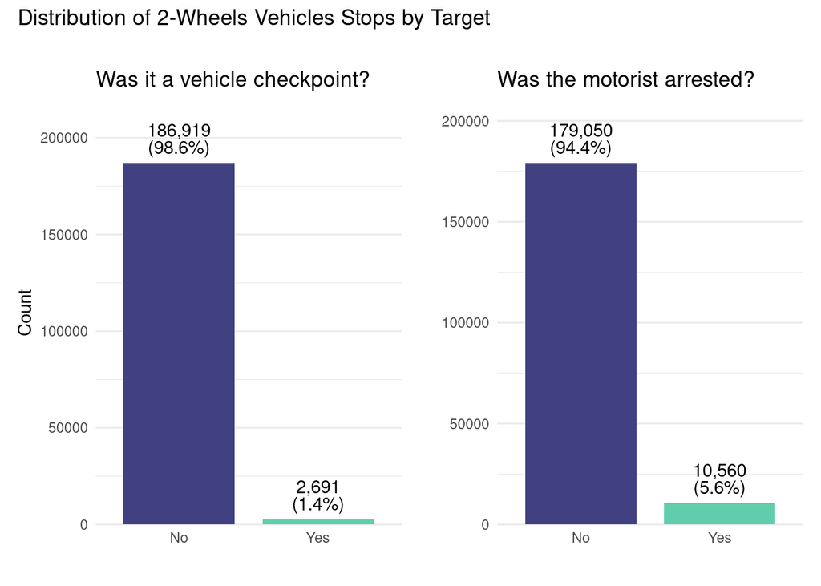

```r
p1 <- plot_binary_bar(
  vehstops, veh_checkpoint,
  "No", "Yes",
  "", "Count", "Was it a vehicle checkpoint?"
)

p2 <- plot_binary_bar(
  vehstops, arrested,
  "No", "Yes",
  "", "", "Was the motorist arrested?"
)

row1 <- p1 | p2

row1 +
plot_layout(heights = c(1, 0.080, 1), guides = "collect") +
plot_annotation(title = "Distribution of 2-Wheels Vehicles Stops by Target") &
theme(legend.position = "bottom")
```

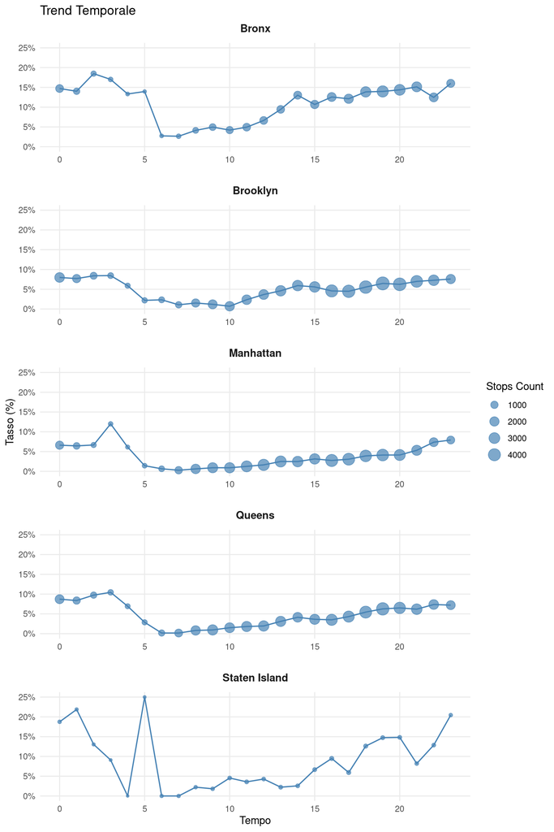

```r
plot_temporal_split(
  vehstops, X_VAR = hour, Z_VAR = area, TARGET = arrested,
  metric = "rate",
  style = "facet",
  x_title = "Tempo", y_title = NULL, title = "Trend Temporale"
)
```

What can we say?

- **Key finding**: The dataset, for 2 wheels-vehicles, **exhibits extreme class imbalance**. Vehicle checkpoints are highly sparse, representing only approximately 1.4% of the total stops (2,691 “Yes” out of 189,610 total records). The same goes for arrests which happen approximately 5.6% of the times (10,560 “Yes” out of 189,610 total records).
- **Interpretation**: Both targets constitute “rare events” when we contemplate the stops of 2-wheels vehicles. The distribution of `veh_checkpoint` indicates that the vast majority of stops are tied to standard patrol or traffic-related events. In fact, checkpoint operations are infrequent activities. On the other hand, arrests are more frequent than checkpoint stops by a factor of nearly 4:1, but they still remain an infrequent occurrence with respect to the total volume of police interactions.
- **Comment**: The high class disparity *renders global accuracy a limiting metric* for our models’ evaluation. This is due to the fact a predictive model optimizing for accuracy could attain an score of ~98.6% by simply classifying every stop as “No”. Therefore, it completely fails to capture the latent features that characterize a checkpoint stop. This is also sub-optimal for our research, as capturing true arrest patterns is central to our investigation into enforcement bias.
- **Proposed Action**: Although we could employ cost-sensitive learning models, this is outside the scope of the course. Given the limitations of our available model suite, we will **employ stratified down-sampling of the majority class** (“No”) to create a balanced training set, ensuring compatibility across all models (LDA, QDA, KNN, etc…). For the **GLM-based models** (Logistic, Lasso, Ridge), we will specifically **utilize observation weighting within the likelihood function** to account for the class disparity. Finally, we will move away from the default 0.5 classification threshold, **optimizing the decision boundary based on the Precision-Recall curve** to ensure our model maintains sensitivity to the minority class (“Yes”).

## Command Unit, Geospatial and Area-related predictors

### Area

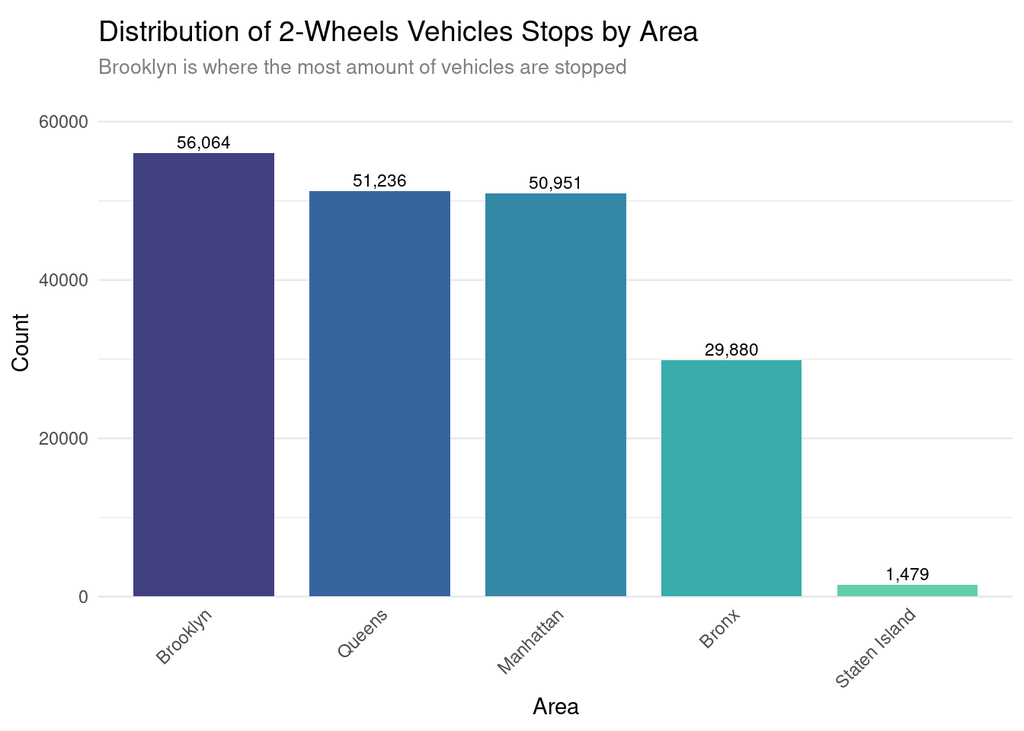

```r
plot_univariate_cat(
  DF = vehstops,
  FEATURE = area,
  X_LABEL = "Area",
  TITLE = "Distribution of 2-Wheels Vehicles Stops by Area",
  SUBTITLE = "Brooklyn is where the most amount of vehicles are stopped",
  order_by = "freq"
)
```

What can we say?

- Key finding: There is a high degree of variance in the volume of stops across areas. We observe three “high-volume” areas (Brooklyn, Queens, and Manhattan) with comparable stop counts (ranging between ~50k and 56k), one “medium-volume” area (Bronx, ~30k), and a distinct “low-volume” area (Staten Island, ~1.5k).
- Interpretation: The distribution is highly non-uniform, or better, uneven. The lower frequency of stops in the Bronx and Staten Island suggests that geographic location could be a strong predictor of the probability of being stopped (in case the targets’ ratio distributed by area follows a specific pattern).
- Comment: From a modeling perspective, this introduces a risk of **overfitting to the high-volume areas**. Since some of the available models (especially KNN or QDA) rely on local neighborhood data or global likelihoods, they will naturally prioritize minimizing errors in the areas with the most observations. Furthermore, the extreme sparsity of the Staten Island group may lead to high variance in the parameter estimates for that specific categorical level, potentially skewing the coefficients for the area predictor.
- Proposed Action: We still need to check its correlation with subject-related predictors. Also, we prefer to explore finer-grained versions of this geographical predictor, which may be able to yield better results when used in the models. Later on, we will use dummy coding to represent the areas, but we will interpret the coefficients with caution (which is our to-go tactic for most categorical variables). However, when using **Lasso or Ridge regression**, we will carefully tune the penalty parameter ($\lambda$) to ensure that the “Area” coefficients are not artificially inflated or suppressed due to the sample size disparity.

### Borough

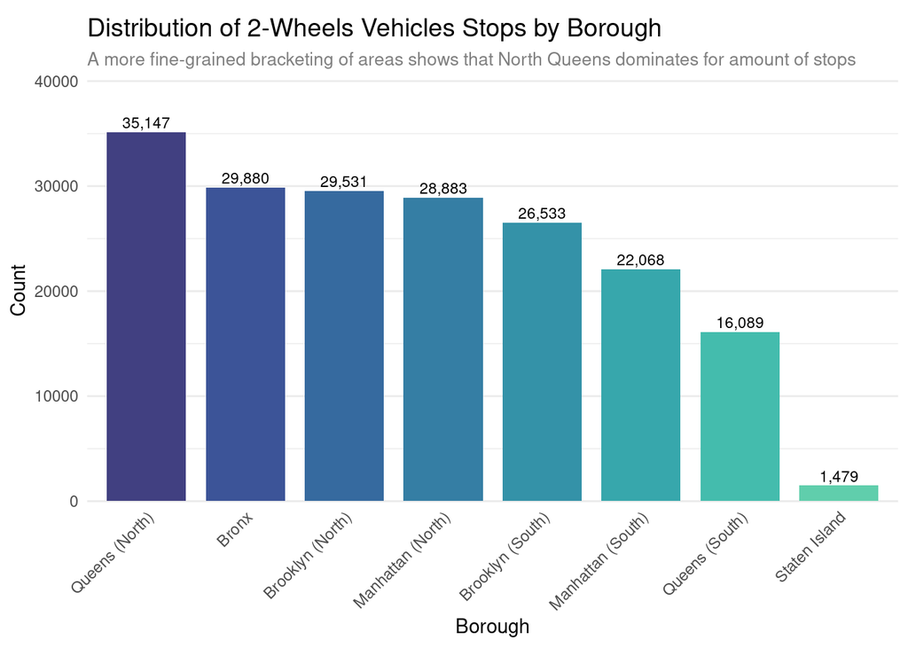

```r
plot_univariate_cat(
  DF = vehstops,
  FEATURE = boro,
  X_LABEL = "Borough",
  TITLE = "Distribution of 2-Wheels Vehicles Stops by Borough",
  SUBTITLE = "A more fine-grained bracketing of areas shows that North Queens dominates for amount of stops"
)
```

What can we say?

- Key finding: The comparison reveals that while “Staten Island” is uniformly sparse, boroughs like “Queens” and “Manhattan” are internally heterogeneous. Aggregating sub-boroughs into a single `area` feature assumes that police behavior is homogeneous across those sub-sectors.
- Interpretation: If the arrest rate in “North West Queens” (a high-volume area) is statistically distinct from “South Queens,” the `area` variable acts as a source of **aggregation bias**. By averaging these rates, we lose the model’s ability to differentiate between high-risk and low-risk zones within the same borough, potentially obscuring patterns of excessive enforcement. On the other hand, in a regression or classification context, this means our parameter estimates for these low-frequency categories will likely suffer from high variance and wide confidence intervals, making them unreliable indicators of systematic enforcement bias.
- Comment: Discarding granularity prematurely is a legitimate methodological risk. If a specific sub-borough has a disproportionately higher event rate than its parent borough, the model will fail to capture that specific hotspot. We should not treat granularity as “noise” until we have empirical evidence that the target ratios are homogeneous within the boroughs. In fact, if the target ratio (arrest or checkpoint probability) differs significantly between “North West Queens” and “South Queens,” aggregating them into a single “Queens” category would indeed “wash out” a genuine, predictive signal, resulting in an under-fitted model.
- Proposed Action: As previously stated, we wish to plot the arrest/checkpoint rate for each borough level, as well for the areas. Then, based on our observations, we could train two alternative versions of the same model using `area` and `boro`. In fact, we could employ means of model comparison (for instance, Stratified K-fold Cross Validation) and, in case the granular version yields lower CV error, we may be able to discard the hypothesis of introducing noise/variability.

### Latitude and Longitude for Stop Density

For what concerns these two predictors, we will use the to plot a spatial heat map of the stops with these values available.

```r
# Download NYC Borough boundaries once
nyc_map <- counties(state = "NY", cb = TRUE) %>%
  filter(NAME %in% c("Bronx", "Kings", "New York", "Queens", "Richmond"))
```

[output not shown]

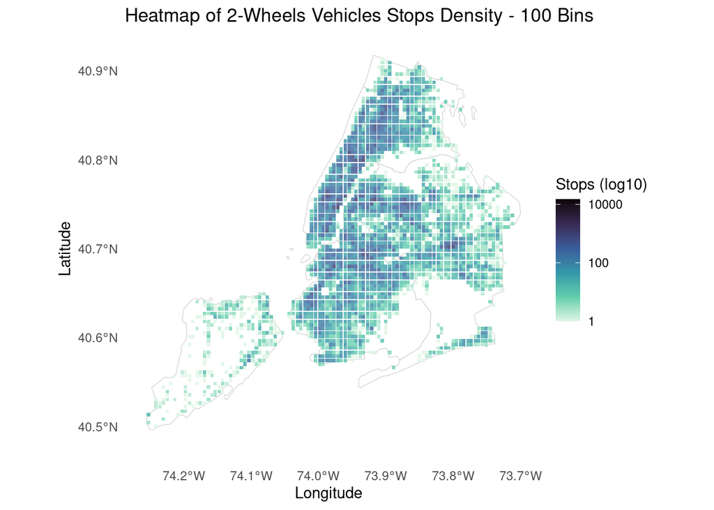

```r
# 1. Define the grid resolution (match this with your desired density)
bins <- 100
lon_breaks <- seq(-74.26, -73.71, length.out = bins + 1)
lat_breaks <- seq(40.48, 40.92, length.out = bins + 1)

# 2. Generate the grid_sum object from your main data
grid_sum <- vehstops %>%
  filter(!is.na(longitude) & !is.na(latitude)) %>%
  mutate(
    xbin = cut(longitude, breaks = lon_breaks, include.lowest = TRUE, right = FALSE),
    ybin = cut(latitude, breaks = lat_breaks, include.lowest = TRUE, right = FALSE)
  ) %>%
  # Extract the center point of each bin for the tile plot
  mutate(
    x = as.numeric(gsub(".*\\[(.*),.*", "\\1", xbin)) + (lon_breaks[2] - lon_breaks[1])/2,
    y = as.numeric(gsub(".*\\[(.*),.*", "\\1", ybin)) + (lat_breaks[2] - lat_breaks[1])/2
  ) %>%
  group_by(x, y) %>%
  summarise(n = n(), .groups = "drop")

# Plot with base layer
ggplot() +
  # Add NYC base layer
  geom_sf(data = nyc_map, fill = "white", color = "grey80", size = 0.2) +
  # Add density data on top
  geom_tile(data = grid_sum, aes(x, y, fill = n), alpha = 0.8) +
  # Use a more high-contrast color scale
  scale_fill_viridis_c(trans = "log10", name = "Stops (log10)", option = "mako", direction = -1) +
  coord_sf(xlim = c(-74.26, -73.71), ylim = c(40.48, 40.92)) +
  theme_minimal() +
  theme(panel.grid = element_blank()) +
  labs(title = "Heatmap of 2-Wheels Vehicles Stops Density - 100 Bins", x = "Longitude", y = "Latitude")
```

What can we say?

- Key finding: The heatmap reveals a highly heterogeneous spatial distribution, characterized by distinct high-density corridors and hotspots.
- Interpretation: This spatial clustering indicates that police enforcement is not randomly distributed; it is structurally tied to urban infrastructure, likely following major traffic arteries or high-activity transit corridors.
- Comment: Again, high stop density does not necessarily imply aggressive policing; it may simply reflect high traffic exposure. Also, this plot just give us an idea, because we are skipping over missing data.
- Proposed Action: To prevent data leakage we cannot just include then in the models. These two predictors will be later removed.

## Time-related predictors

### Year

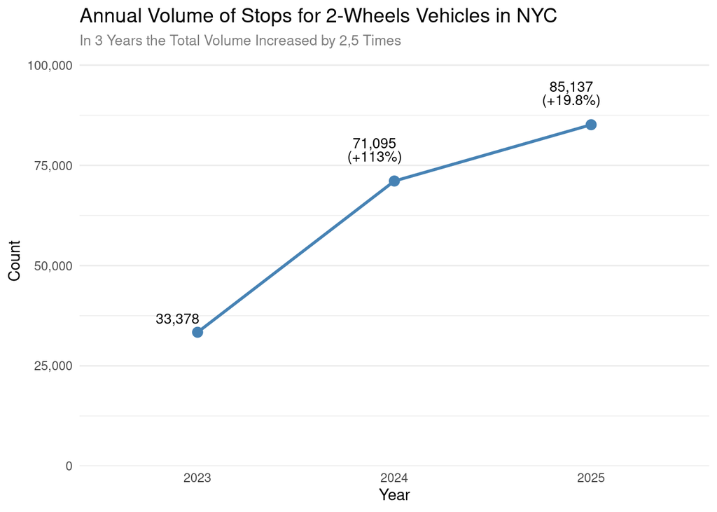

```r
vehstops %>%
  filter(!is.na(year)) %>%
  count(year) %>%
  mutate(year = as.numeric(as.character(year))) %>%
  arrange(year) %>%
  # 1. Calculate growth and create the combined label
  mutate(
    prev_n = lag(n), pct_change = (n - prev_n) / prev_n * 100,
    # Combine count and percentage with a newline character
    label_text = ifelse(
      is.na(pct_change),
      comma(n),
      paste0(comma(n), "\n(", ifelse(pct_change > 0, "+", ""), round(pct_change, 1), "%)")
    )) %>%
  ggplot(aes(x = factor(year), y = n, group = 1)) +
  # Draw the trend line
  geom_line(color = "steelblue", linewidth = 1) +
  # Add points for clarity
  geom_point(color = "steelblue", size = 3) +
  # 2. Add the combined label
  # vjust = -0.5 helps center the multi-line text just above the point
  geom_text(aes(label = label_text), vjust = -0.8, nudge_x = -0.1, size = 3.5, lineheight = 0.8) +
  # Increase top expansion (0.3) to accommodate the taller labels
  scale_y_continuous(labels = comma, limits = c(0, NA), expand = expansion(mult = c(0, 0.2))) +
  theme_minimal() +
  theme(
    panel.grid.major.x = element_blank(),
    plot.title = element_text(size = 14),
    plot.subtitle = element_text(size = 10, color = "grey50")
    ) +
  labs(
    title = "Annual Volume of Stops for 2-Wheels Vehicles in NYC",
    subtitle = "In 3 Years the Total Volume Increased by 2,5 Times",
    x = "Year", y = "Count"
    )
```

What can we say?

- Key finding: There has been a significant, multi-year surge in the volume of police stops involving 2-wheeled vehicles, with the number of encounters increasing from ~33k in 2023 to ~85k in 2025.
- Interpretation: The growth trajectory is non-linear. The 113% jump between 2023 and 2024 represents a massive inflection point, which is suggesting either a shift in departmental priority or a new legislation targeting these vehicles. On the other hand, the 19.8% increase in 2025 indicates that while activity is still rising, the rate of acceleration is starting to stabilize.
- Comment: The visualization clearly demonstrates that the “enforcement burden” or “public exposure” to these stops is intensifying. However, since the dataset analyzed was aggregated by 2-wheels vehicles, we could be seeing the result of policies regarding a specific subset. Plus, 3 years is not a sufficient time span for us to deliver some substantial proof.
- Proposed Action: We are going to look for some level of contextualization, in order to see if something changed during late 2023 or early 2024.

In fact, we found the article [“New York City Council Votes to Pass New E-Bike Safety Rules in Continued Effort to Address the Dangers of Lithium-Ion Batteries”](https://council.nyc.gov/press/2024/02/28/2564/) published in February 28, 2024. From its content, we could justify the raise in volume as natural consequence to new laws being put in place.

### Month

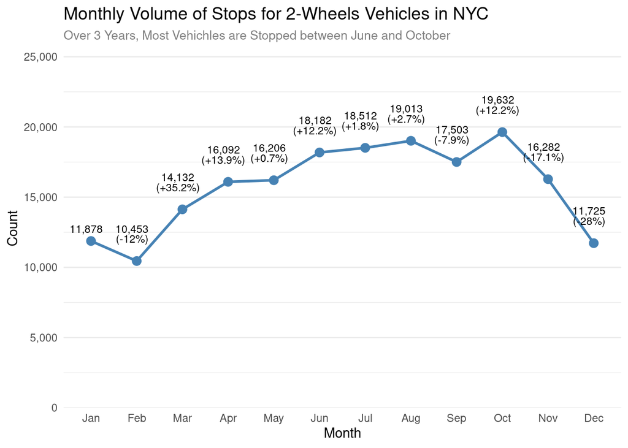

```r
# Aggregate and calculate monthly change
month_data <- vehstops %>%
  filter(!is.na(month)) %>%
  count(month) %>%
  mutate(month = factor(month, levels = 1:12)) %>%
  arrange(month) %>%
  mutate(
    prev_n = lag(n), pct_change = (n - prev_n) / prev_n * 100,
    # Create the label: Count on top, Percentage on bottom
    label_text = ifelse(
      is.na(pct_change), comma(n),
      paste0(comma(n), "\n(", ifelse(pct_change > 0, "+", ""), round(pct_change, 1), "%)"))
  )

# Plot
month_data %>%
  ggplot(aes(x = month, y = n, group = 1)) +
  geom_line(color = "steelblue", linewidth = 1) +
  geom_point(color = "steelblue", size = 3) +
  # Apply text tweaks: nudge_x moves it left, vjust raises it
  geom_text(aes(label = label_text), vjust = -1, nudge_x = -0.1, size = 3, lineheight = 0.8) +
  scale_x_discrete(labels = month.abb) +
  scale_y_continuous(labels = comma, limits = c(0, NA), expand = expansion(mult = c(0, 0.3))) +
  theme_minimal() +
  theme(
    panel.grid.major.x = element_blank(),
    plot.title = element_text(size = 14),
    plot.subtitle = element_text(color = "grey50", size = 10) # Styled as requested
  ) +
  labs(
    title = "Monthly Volume of Stops for 2-Wheels Vehicles in NYC",
    subtitle = "Over 3 Years, Most Vehichles are Stopped between June and October",
    x = "Month",
    y = "Count"
  )
```

What can we say?

- Key finding: The data exhibits strong seasonality, with stop volumes peaking in a sustained plateau between June and October (roughly 18k–19k stops/month). Enforcement bottoms out in the winter, with the sharpest declines occurring in November (-17%) and December (-28%).
- Interpretation: The stop volume is likely a direct proxy for “exposure.” As temperatures rise, more 2-wheeled vehicles are on the road, increasing the opportunity for police to conduct stops. The “plateau” from June through October suggests that once the weather is consistently warm, ridership hits a saturation point, and enforcement activity maintains a high, stable operational baseline.
- Comment: The sharp drops at the end of the year demonstrate that enforcement is reactive: it tracks the behavior of the riders. In other words, the decline in stops during winter is likely due to **reduced vehicle usage** rather than a change in police behavior.
- Proposed Action: Given this clear seasonal pattern, we ensure our predictive models to include this time-related feature.

Let us see this with respect to the year

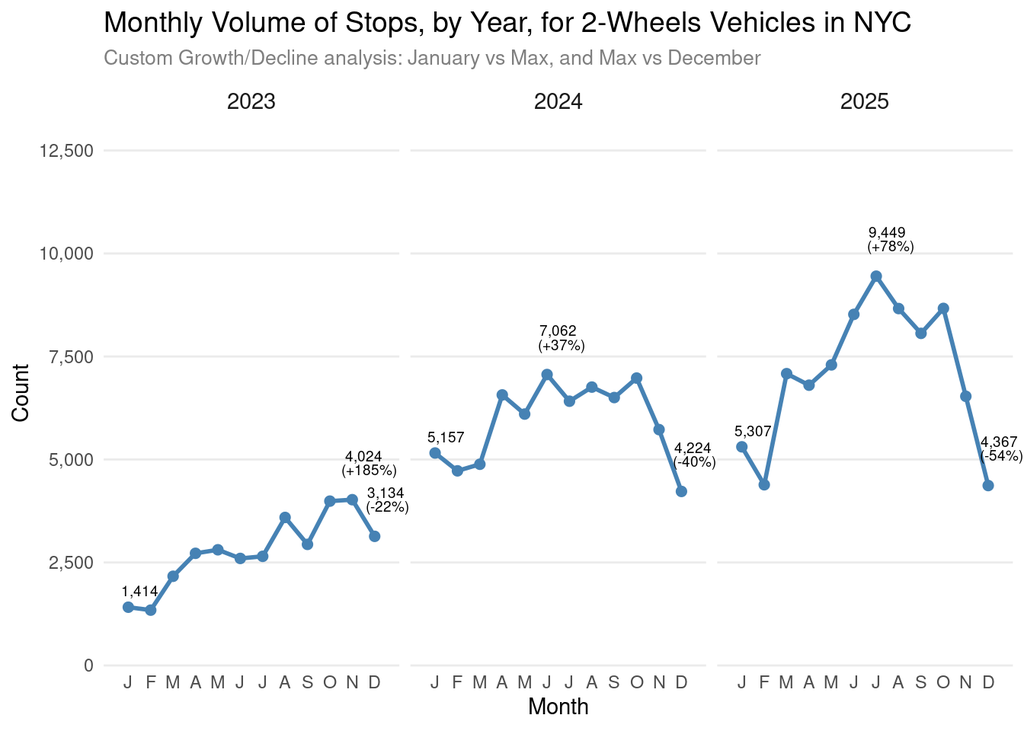

```r
# Data prep with explicit "+" sign logic
plot_data <- vehstops %>%
  filter(!is.na(year) & !is.na(month)) %>%
  count(year, month) %>%
  mutate(month = factor(month, levels = 1:12)) %>%
  group_by(year) %>%
  mutate(
    n_jan = n[month == 1],
    n_max = max(n),
    is_max = n == n_max,
    # Pre-calculate percentages for cleaner label logic
    pct_max = round((n - n_jan) / n_jan * 100, 0),
    pct_dec = round((n - n_max) / n_max * 100, 0),

    # Custom Label Logic
    label_text = case_when(
      month == 1 ~ comma(n),
      is_max ~ paste0(comma(n), "\n(", ifelse(pct_max > 0, "+", ""), pct_max, "%)"),
      month == 12 ~ paste0(comma(n), "\n(", pct_dec, "%)"), # Dec is usually negative, so '-' is automatic
      TRUE ~ ""
    )
  )

# Faceted plot
plot_data %>%
  ggplot(aes(x = month, y = n, group = 1)) +
  geom_line(color = "steelblue", linewidth = 1) +
  geom_point(color = "steelblue", size = 2) +
  geom_text(aes(label = label_text), vjust = -1, hjust = 0.2, size = 2.5, lineheight = 0.8) +
  facet_wrap(~year, nrow = 1) +
  scale_x_discrete(
    labels = c("J", "F", "M", "A", "M", "J", "J", "A", "S", "O", "N", "D"),
    expand = expansion(mult = c(0.1, 0.1))
    ) +
  scale_y_continuous(labels = comma, limits = c(0, NA), expand = expansion(mult = c(0, 0.4))) +
  coord_cartesian(clip = "off") +
  theme_minimal() +
  theme(
    panel.grid.major.x = element_blank(),
    panel.grid.minor = element_blank(),
    plot.title = element_text(size = 14),
    plot.subtitle = element_text(color = "grey50", size = 10),
    strip.text = element_text(size = 11)
  ) +
  labs(
    title = "Monthly Volume of Stops, by Year, for 2-Wheels Vehicles in NYC",
    subtitle = "Custom Growth/Decline analysis: January vs Max, and Max vs December",
    x = "Month",
    y = "Count"
  )
```

What can we say?

### Checking out `hot_season`

Let us proceed with this intuition

```r
vehstops <- vehstops %>%
  mutate(hot_season = ifelse(month %in% 4:10, 1, 0))
```

Now, for plotting

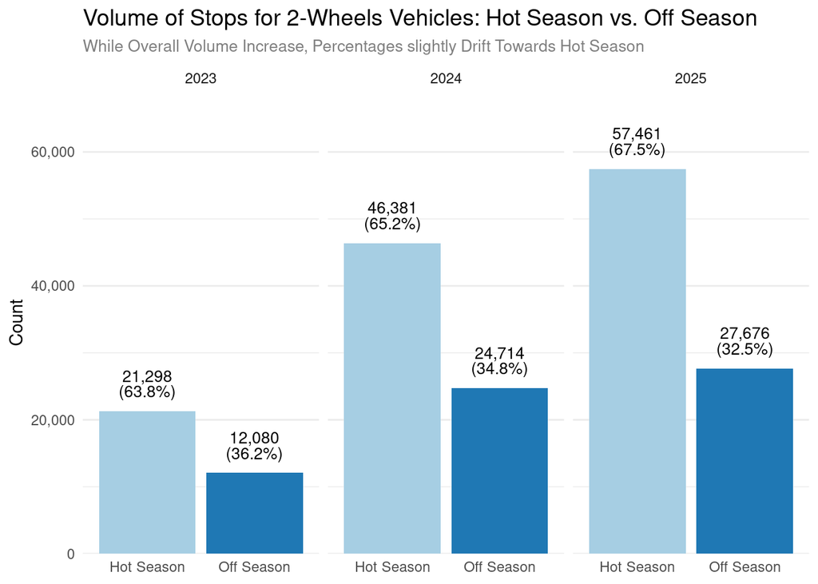

```r
# 1. Create the indicator, count, and calculate percentages
plot_data <- vehstops %>%
  filter(!is.na(year) & !is.na(month)) %>%
  mutate(
    is_hot_season = ifelse(month %in% 4:10, "Hot Season", "Off Season"),
    is_hot_season = factor(is_hot_season, levels = c("Hot Season", "Off Season"))
  ) %>%
  count(year, is_hot_season) %>%
  group_by(year) %>%
  mutate(
    year_total = sum(n),
    pct = n / year_total,
    # Combine count and percentage into a single label string
    label_text = paste0(comma(n), "\n(", round(pct * 100, 1), "%)")
  )

# 2. Build the faceted barplot
plot_data %>%
  ggplot(aes(x = is_hot_season, y = n, fill = is_hot_season)) +
  geom_col(show.legend = FALSE) +
  # Facet by year
  facet_wrap(~year, nrow = 1) +
  # Add labels: count on top, percentage below
  geom_text(aes(label = label_text), vjust = -0.5, size = 3.5, lineheight = 0.8) +
  # Add vertical breathing room for the text
  scale_y_continuous(labels = comma, expand = expansion(mult = c(0, 0.2))) +
  scale_fill_brewer(palette = "Paired") +
  theme_minimal() +
  theme(
    panel.grid.major.x = element_blank(),
    plot.title = element_text(size = 14),
    plot.subtitle = element_text(color = "grey50", size = 10)
  ) +
  labs(
    title = "Volume of Stops for 2-Wheels Vehicles: Hot Season vs. Off Season",
    subtitle = "While Overall Volume Increase, Percentages slightly Drift Towards Hot Season",
    x = NULL,
    y = "Count"
  )
```

What can we say?

- Key finding: Total enforcement volume is surging, but more importantly, the enforcement pattern is becoming **increasingly concentrated** in the “Hot Season.” While the hot season accounted for ~64% of stops in 2023, it climbed to ~68% of stops in 2025.
- Interpretation: The growth in stops is not uniform throughout the year. The rising percentage indicates that the “Hot Season” (April–Oct) is becoming a disproportionately larger driver of total annual stops year-over-year. This suggests that the NYPD’s enforcement efforts for 2-wheelers are becoming more sensitive—or reactive—to the seasonal influx of riders.
- Comment: This plot confirms that `hot_season` could be a “high-signal” feature.
- Proposed Action: We could either use it in place of the month, or make it an interaction term with `year` (i.e., `is_hot_season * year`).

### Dow/Weekday, Day and Doy

We have decided to exclude ‘Day of Month’ (`day`) and ‘Day of Year’ (`doy`) from our feature set to mitigate ‘calendar artifact’ bias. These variables introduce artificial statistical noise rather than genuine operational signals.

As we can see below, the structural variation in month length creates false activity dips for end-of-month dates

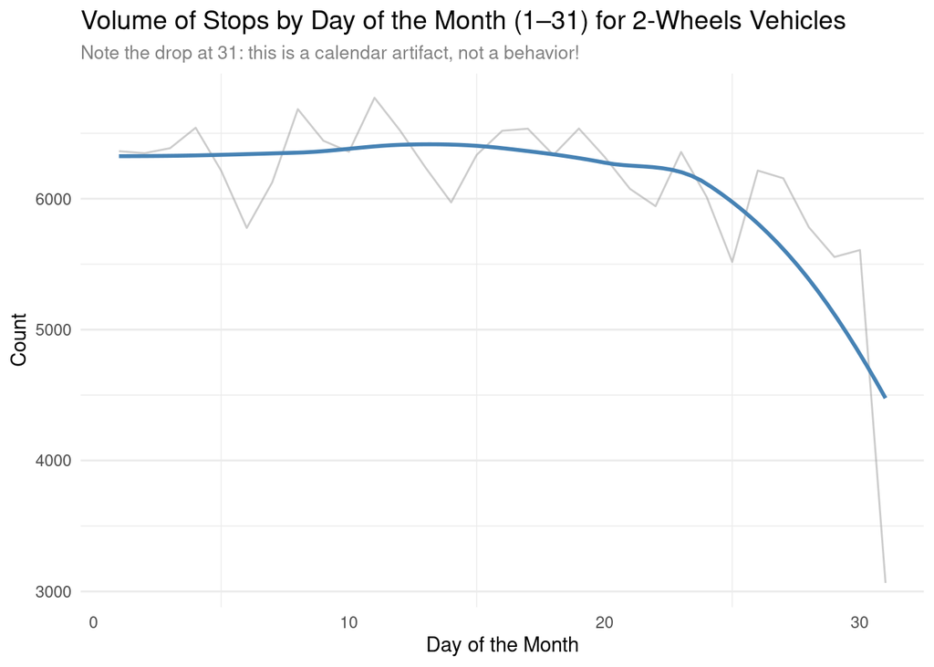

```r
vehstops %>%
  filter(!is.na(day)) %>%
  count(day) %>%
  ggplot(aes(x = day, y = n)) +
  geom_line(color = "grey60", alpha = 0.5) +
  geom_smooth(method = "loess", color = "steelblue", se = FALSE) +
  theme_minimal() +
   theme(
    panel.grid.major.x = element_blank(),
    plot.title = element_text(size = 14),
    plot.subtitle = element_text(color = "grey50", size = 10)
  ) +
  labs(title = "Volume of Stops by Day of the Month (1–31) for 2-Wheels Vehicles",
       subtitle = "Note the drop at 31: this is a calendar artifact, not a behavior!",
       x = "Day of the Month", y = "Count")
```

Furthermore, `doy` variable suffers from inconsistent data density.

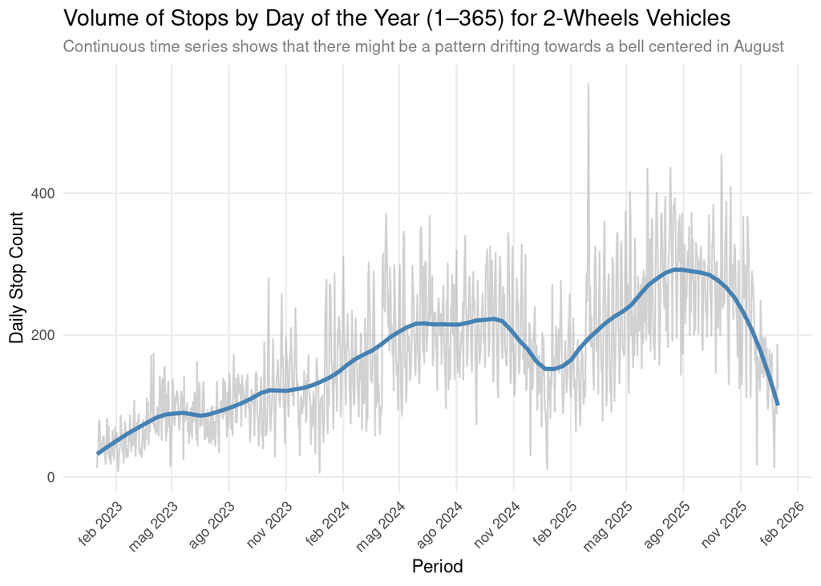

```r
# 1. Ensure you have a Date object
# If you don't have a 'date' column, create one from year, month, day
plot_data <- vehstops %>%
  mutate(date = as.Date(paste(year, month, day, sep = "-"))) %>%
  count(date)

# 2. Plot the timeline
plot_data %>%
  ggplot(aes(x = date, y = n)) +
  # Raw data points (using alpha to reduce overplotting)
  geom_line(color = "grey70", alpha = 0.6, linewidth = 0.5) +
  # Trend line (using a slightly larger span to show the multi-year trajectory)
  geom_smooth(method = "loess", span = 0.2, color = "steelblue", se = FALSE, linewidth = 1.2) +
  scale_x_date(date_breaks = "3 months", date_labels = "%b %Y") +
  theme_minimal() +
  theme(
    panel.grid.minor = element_blank(),
    axis.text.x = element_text(angle = 45, hjust = 1),
    plot.title = element_text(size = 14),
    plot.subtitle = element_text(color = "grey50", size = 10)
  ) +
  labs(
    title = "Volume of Stops by Day of the Year (1–365) for 2-Wheels Vehicles",
    subtitle = "Continuous time series shows that there might be a pattern drifting towards a bell centered in August",
    x = "Period",
    y = "Daily Stop Count"
  )
```

While we observe a consistent seasonal clustering peaking in late summer, our current 3-year dataset captures three seasonal cycles. This is sufficient to identify a recurring pattern, but insufficient to establish it as a long-term trend.

The next plot, demonstrates high daily volatility (indicated by the grey jitter) that significantly obscures the underlying seasonal trend (the blue trend line). Because the daily fluctuation is massive relative to the overall pattern, including ‘Day of Year’ as a feature risks overfitting.

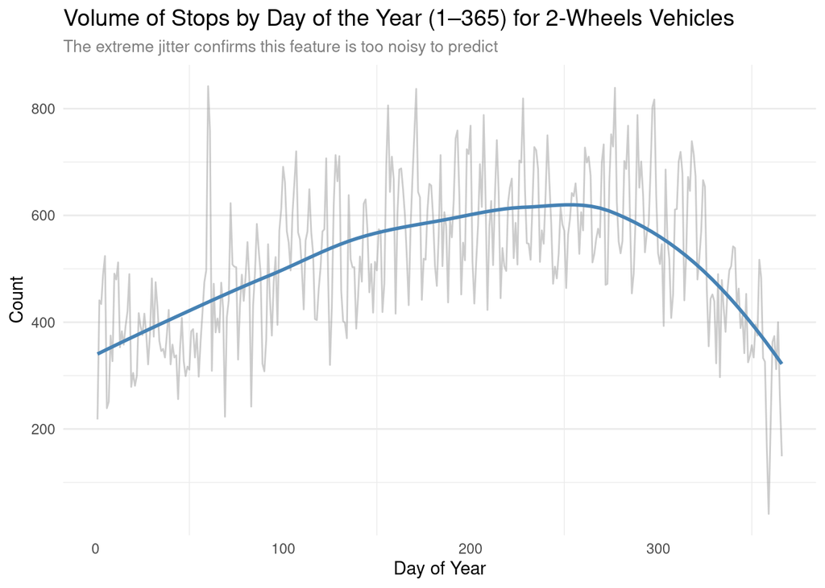

```r
vehstops %>%
  filter(!is.na(doy)) %>%
  count(doy) %>%
  ggplot(aes(x = doy, y = n)) +
  geom_line(color = "grey60", alpha = 0.5) +
  geom_smooth(method = "loess", color = "steelblue", se = FALSE) +
  theme_minimal() +
   theme(
    panel.grid.major.x = element_blank(),
    plot.title = element_text(size = 14),
    plot.subtitle = element_text(color = "grey50", size = 10)
  ) +
  labs(title = "Volume of Stops by Day of the Year (1–365) for 2-Wheels Vehicles",
       subtitle = "The extreme jitter confirms this feature is too noisy to predict",
       x = "Day of Year", y = "Count")
```

Finally, these granular temporal markers are prone to overfitting. Excluding them allows the model to focus on more robust predictors, such as seasonality and weekly rhythms.

On the other hand, we can study the “Day of the Week” which usually abstract better.

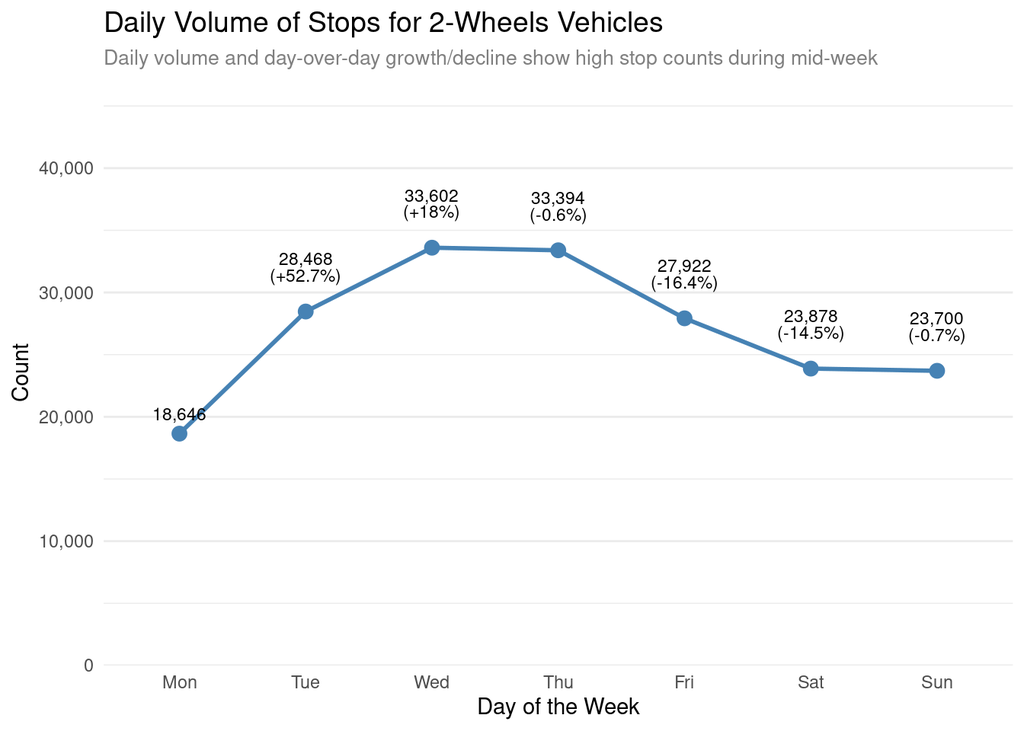

```r
vehstops %>%
  filter(!is.na(dow)) %>%
  count(dow) %>%
  mutate(
    dow = factor(dow, levels = 1:7,
                 labels = c("Mon", "Tue", "Wed", "Thu", "Fri", "Sat", "Sun")),
    # Calculate % change relative to the previous day
    pct_change = (n - lag(n)) / lag(n) * 100,
    # Create the label: Count on top, % change on bottom
    label_text = ifelse(is.na(pct_change),
                        comma(n),
                        paste0(comma(n), "\n(", ifelse(pct_change > 0, "+", ""), round(pct_change, 1), "%)"))
  ) %>%
  ggplot(aes(x = dow, y = n, group = 1)) +
  geom_line(color = "steelblue", linewidth = 1) +
  geom_point(color = "steelblue", size = 3) +
  # vjust = -0.6 lifts text off the point, lineheight compacts the text
  geom_text(aes(label = label_text), vjust = -1, size = 3, lineheight = 0.8) +
  scale_y_continuous(labels = comma,
                     limits = c(0, NA),
                     expand = expansion(mult = c(0, 0.4))) + # Extra room for labels
  theme_minimal() +
  theme(
    panel.grid.major.x = element_blank(),
    plot.title = element_text(size = 14),
    plot.subtitle = element_text(color = "grey50", size = 10)
  ) +
  labs(
    title = "Daily Volume of Stops for 2-Wheels Vehicles",
    subtitle = "Daily volume and day-over-day growth/decline show high stop counts during mid-week",
    x = "Day of the Week",
    y = "Count"
  )
```

What can we say?

- Key finding: Enforcement activity follows a distinct “Mid-Week Peak” cycle. The volume starts at its lowest on Monday, surges aggressively (+52.7%) into Tuesday, peaks on Wednesday/Thursday, and then exhibits a sustained decline toward the weekend.
- Interpretation: This pattern strongly suggests that these stops are primarily linked to **commercial usage** (e.g., food delivery/courier services) rather than recreational riding. Recreational riders typically peak on weekends; the fact that your stops drop off on Saturday and Sunday reinforces that this enforcement is targeting “work-hour” traffic. The +52% jump from Monday to Tuesday is the most critical signal here—it suggests that Monday may be a “low volume” day for this specific gig-economy demographic, or that enforcement resources are being ramped up as the work week settles into its rhythm.
- Comment: We have identified a non-linear relationship: the “Day of Week” effect isn’t a straight line, it’s a curve.
- Proposed Action: We may keep `weekday` as the new `day` in the model, and even think about an interaction with `hot_season`. Also we need first to check the signal from other indicators previously built.

### Hour and Time Bracket

First of all we look at the overall cycle of stops volume

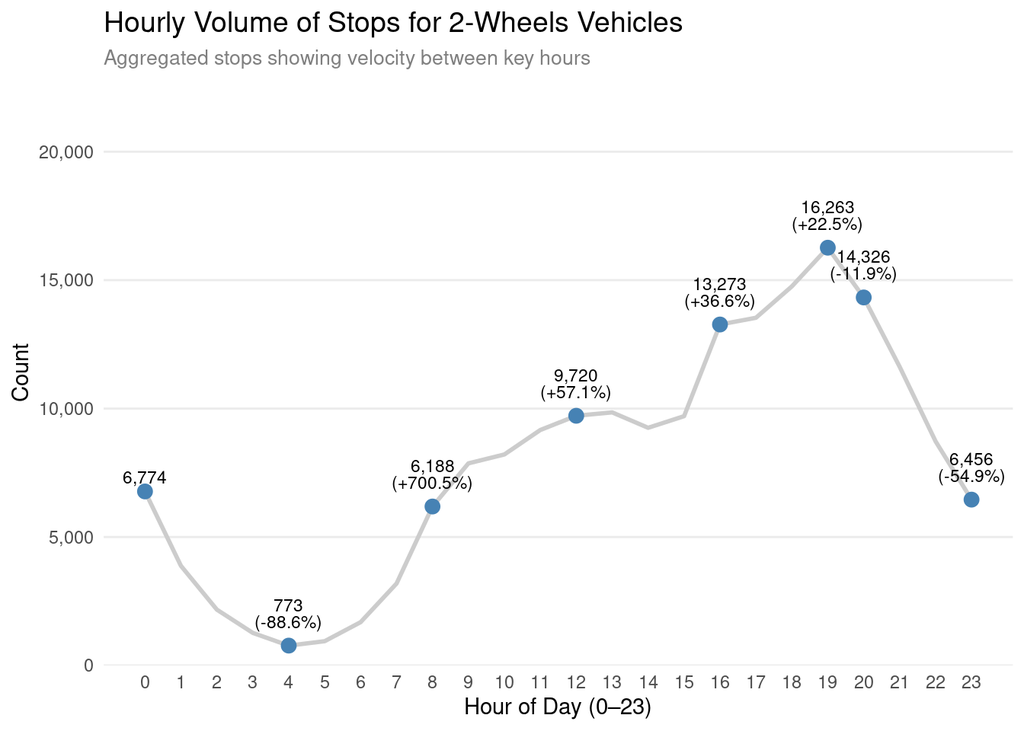

```r
# 1. Define the specific hours you want to highlight
hours_to_show <- c(0, 4, 8, 12, 16, 19, 20, 23)

# 2. Prepare the full dataset for the background line
full_data <- vehstops %>%
  filter(!is.na(hour)) %>%
  count(hour)

# 3. Prepare the highlighted data for points and labels
highlight_data <- full_data %>%
  filter(hour %in% hours_to_show) %>%
  arrange(hour) %>%
  mutate(
    # Percent change relative to the PREVIOUS HOUR IN THE LIST
    pct_change = (n - lag(n)) / lag(n) * 100,
    label_text = ifelse(
      is.na(pct_change),
      comma(n),
      paste0(comma(n), "\n(", ifelse(pct_change > 0, "+", ""), round(pct_change, 1), "%)"))
  )

# 4. Plot
ggplot() +
  # Background line showing the full 24-hour context
  geom_line(data = full_data, aes(x = hour, y = n), color = "grey80", linewidth = 1) +
  # Points and labels for specific hours only
  geom_point(data = highlight_data, aes(x = hour, y = n), color = "steelblue", size = 3) +
  geom_text(data = highlight_data, aes(x = hour, y = n, label = label_text),
            vjust = -0.6, size = 3, lineheight = 0.8) +
  # Scaling and Theme
  scale_x_continuous(breaks = 0:23) +
  scale_y_continuous(labels = comma, limits = c(0, NA), expand = expansion(mult = c(0, 0.4))) +
  theme_minimal() +
  theme(
    panel.grid.major.x = element_blank(),
    panel.grid.minor = element_blank(),
    plot.title = element_text(size = 14),
    plot.subtitle = element_text(color = "grey50", size = 10)
  ) +
  labs(
    title = "Hourly Volume of Stops for 2-Wheels Vehicles",
    subtitle = "Aggregated stops showing velocity between key hours",
    x = "Hour of Day (0–23)",
    y = "Count"
  )
```

What can we say? In our opinion this looks like a “sine wave broken by a bridge”. To be more precise:

- Key finding: Enforcement volume is characterized by a “fractured” daily cycle. It follows a predictable overnight decline and morning ascent (0:00–12:00), but is interrupted by a distinct midday plateau (12:00–15:00) before reaching an aggressive evening peak at 19:00.
- Interpretation: The data behaves like a sine wave that hits a structural impediment at noon. This suggests that the enforcement cycle is divided into two distinct operational phases: the **Morning Phase** (likely commuter-driven) and the **Evening Phase** (likely delivery/service-driven). The plateau is the “bridge” between these two worlds—a period of transition where ridership demographics potentially shift from commuters to service workers. Therefore, the variability during 10:00 to 15:00 is limited because the amount of vehicles on the road remains stable, as well as the police work.
- Comment: This “bridge” (12:00–15:00) is the most revealing part of the graph. If this were a simple, smooth traffic curve, we would expect a direct climb to the peak. The fact that it plateaus indicates a “lull” or a shift in the operational tempo. It proves that a single `rush_hour` binary variable will be insufficient for your model; it will fail to capture the reality that the “evening rush” is a different phenomenon entirely from the “morning commute.”
- Proposed Action: We could optionally modify our bucketing of `time_bracket` into: `Overnight` (22:00–05:00), `Morning_Commute` (06:00–11:00), `Midday_Transition` (12:00–15:00), and `Evening_Peak` (16:00–21:00).

Before anything else, let us see whether this cycle changed throughout the years.

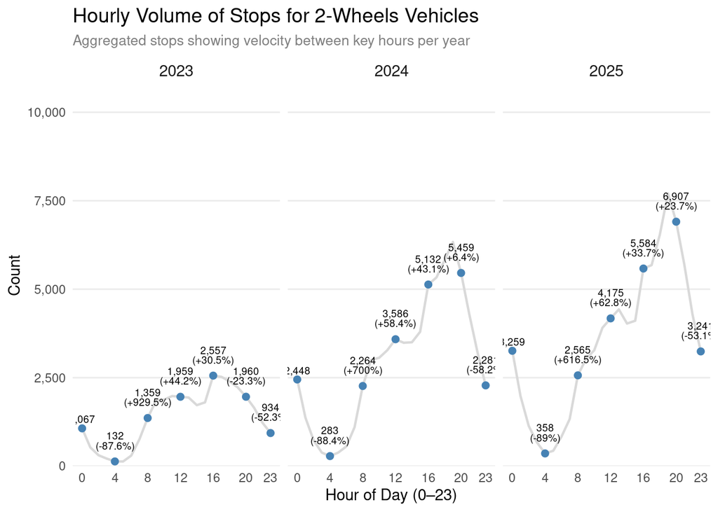

```r
# 1. Define the specific hours you want to highlight
hours_to_show <- c(0, 4, 8, 12, 16, 20, 23)

# 2. Prepare the full background data for the lines
full_data <- vehstops %>%
  filter(!is.na(year) & !is.na(hour)) %>%
  count(year, hour)

# 3. Prepare the highlighted data for points and labels
# We filter for our key hours *before* calculating percentage change
# so it calculates the jump between those specific selected points.
highlight_data <- full_data %>%
  filter(hour %in% hours_to_show) %>%
  group_by(year) %>%
  arrange(hour) %>%
  mutate(
    pct_change = (n - lag(n)) / lag(n) * 100,
    label_text = ifelse(is.na(pct_change),
                        comma(n),
                        paste0(comma(n), "\n(", ifelse(pct_change > 0, "+", ""), round(pct_change, 1), "%)"))
  )

# 4. Plot
ggplot() +
  # Background line showing the full 24-hour context per year
  geom_line(data = full_data, aes(x = hour, y = n), color = "grey85", linewidth = 0.8) +
  # Points and labels for specific hours only
  geom_point(data = highlight_data, aes(x = hour, y = n), color = "steelblue", size = 2) +
  geom_text(data = highlight_data, aes(x = hour, y = n, label = label_text),
            vjust = -0.7, size = 2.5, lineheight = 0.8) +
  # Facet by year
  facet_wrap(~year, nrow = 1) +
  # Scaling and Theme
  scale_x_continuous(breaks = c(0, 4, 8, 12, 16, 20, 23)) +
  scale_y_continuous(labels = comma, limits = c(0, NA), expand = expansion(mult = c(0, 0.4))) +
  theme_minimal() +
  theme(
    panel.grid.major.x = element_blank(),
    panel.grid.minor = element_blank(),
    plot.title = element_text(size = 14),
    plot.subtitle = element_text(color = "grey50", size = 10),
    strip.text = element_text(size = 11)
  ) +
  labs(
    title = "Hourly Volume of Stops for 2-Wheels Vehicles",
    subtitle = "Aggregated stops showing velocity between key hours per year",
    x = "Hour of Day (0–23)",
    y = "Count"
  )
```

What can we say?

Now let us see if the hot season might shift this cycle

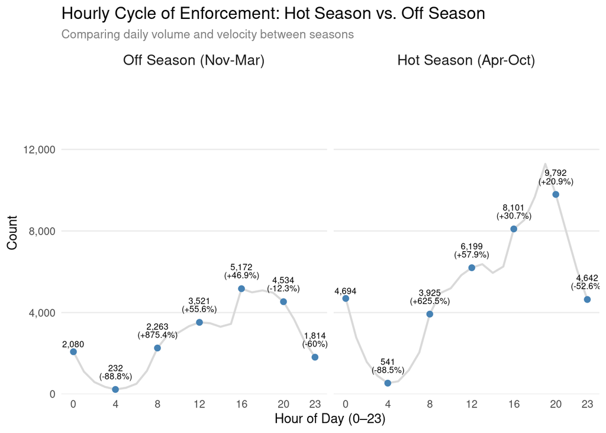

```r
# 1. Prepare data with hot_season variable
# Assuming month column exists. If not, you may need to join/create it.
plot_data_full <- vehstops %>%
  mutate(
    hot_season = ifelse(month %in% 4:10, 1, 0),
    hot_season_label = factor(hot_season, levels = c(0, 1),
                              labels = c("Off Season (Nov-Mar)", "Hot Season (Apr-Oct)"))
  ) %>%
  filter(!is.na(hour))

# 2. Prepare full background data
full_data <- plot_data_full %>%
  count(hot_season_label, hour)

# 3. Define key hours and calculate velocity
hours_to_show <- c(0, 4, 8, 12, 16, 20, 23)

highlight_data <- full_data %>%
  filter(hour %in% hours_to_show) %>%
  group_by(hot_season_label) %>%
  arrange(hour) %>%
  mutate(
    pct_change = (n - lag(n)) / lag(n) * 100,
    label_text = ifelse(is.na(pct_change),
                        comma(n),
                        paste0(comma(n), "\n(", ifelse(pct_change > 0, "+", ""), round(pct_change, 1), "%)"))
  )

# 4. Faceted plot
ggplot() +
  geom_line(data = full_data, aes(x = hour, y = n), color = "grey85", linewidth = 0.8) +
  geom_point(data = highlight_data, aes(x = hour, y = n), color = "steelblue", size = 2) +
  geom_text(data = highlight_data, aes(x = hour, y = n, label = label_text),
            vjust = -0.7, size = 2.5, lineheight = 0.8) +
  facet_wrap(~hot_season_label, nrow = 1) +
  scale_x_continuous(breaks = c(0, 4, 8, 12, 16, 20, 23)) +
  scale_y_continuous(labels = comma, limits = c(0, NA), expand = expansion(mult = c(0, 0.4))) +
  theme_minimal() +
  theme(
    panel.grid.major.x = element_blank(),
    panel.grid.minor = element_blank(),
    plot.title = element_text(size = 14),
    plot.subtitle = element_text(color = "grey50", size = 10),
    strip.text = element_text(size = 12)
  ) +
  labs(
    title = "Hourly Cycle of Enforcement: Hot Season vs. Off Season",
    subtitle = "Comparing daily volume and velocity between seasons",
    x = "Hour of Day (0–23)",
    y = "Count"
  )
```

What can we say?

Let us check the time brackets previously built.

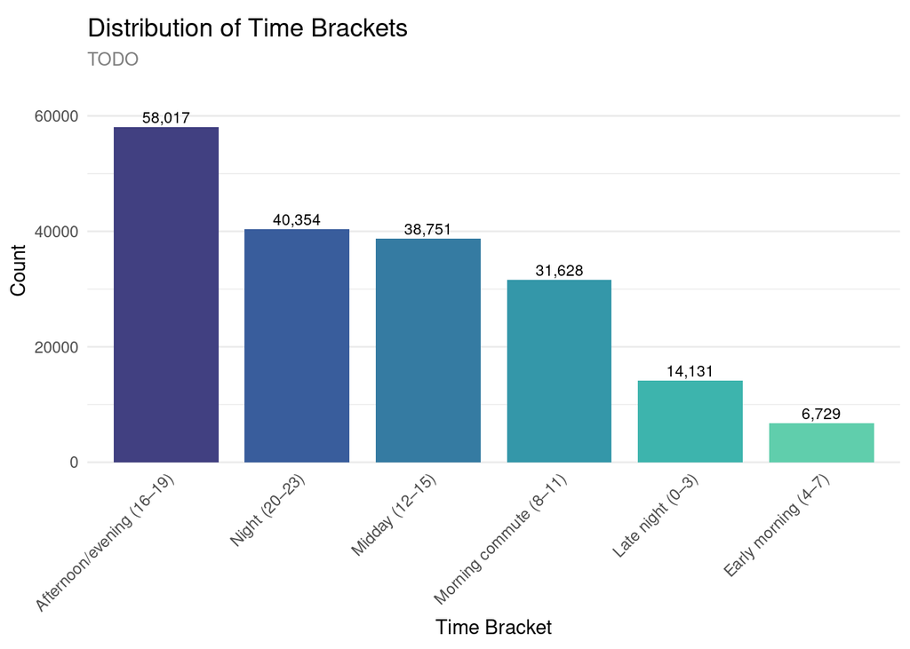

```r
plot_univariate_cat(
  DF = vehstops,
  FEATURE = time_bracket,
  X_LABEL = "Time Bracket",
  TITLE = "Distribution of Time Brackets",
  SUBTITLE = "TODO"
)
```

What can we say?

- Key finding: Enforcement is heavily skewed toward the latter half of the day. The “Afternoon/evening” (16–19) and “Night” (20–23) brackets collectively account for the majority of stops, with the afternoon/evening block acting as the dominant peak. Consistent time-bracket definitions are essential for maintaining longitudinal integrity. Modifying brackets to “fit” observed peaks introduces selection bias that invalidates historical comparisons across your three-year dataset.
- Interpretation: This confirms that the “Evening Migration” we observed in the previous charts is a structural trend. This effectively validates that your categorical buckets align with real-world activity peaks, rather than arbitrary time splits.
- Comment: This is a clean, robust way to feed time data into a machine learning model. By using these brackets, you have significantly reduced the “noise” (like the variance between 16:00 and 17:00) while keeping the “signal” (the fact that 16:00–23:00 is high volume). This reduces the risk of overfitting compared to using the raw hour (0–23) or day_of_year (1–365) variables we discarded earlier.
- Proposed Action: Maintain your existing time_bracket definitions exactly as they are. Instead of changing them, introduce an interaction term (time_bracket * year) in your model.

Also, we are going to drop minute as its level of granularity cannot be properly included in the dataset.

## Motorist related predictors

### Reported Age and Age Bracket

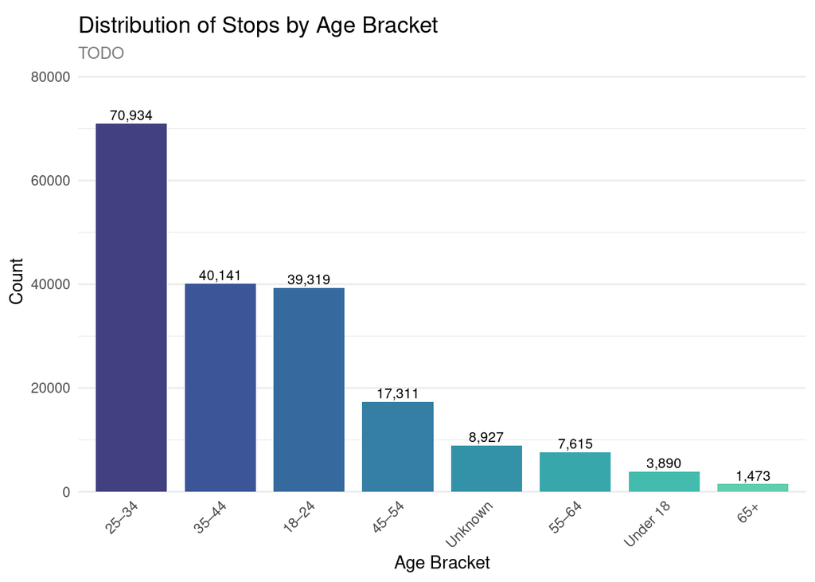

```r
plot_univariate_cat(
  DF = vehstops,
  FEATURE = age_bracket,
  X_LABEL = "Age Bracket",
  TITLE = "Distribution of Stops by Age Bracket",
  SUBTITLE = "TODO"
)
```

What can we say?

And now, let us see how this looks when looking at the full distribution

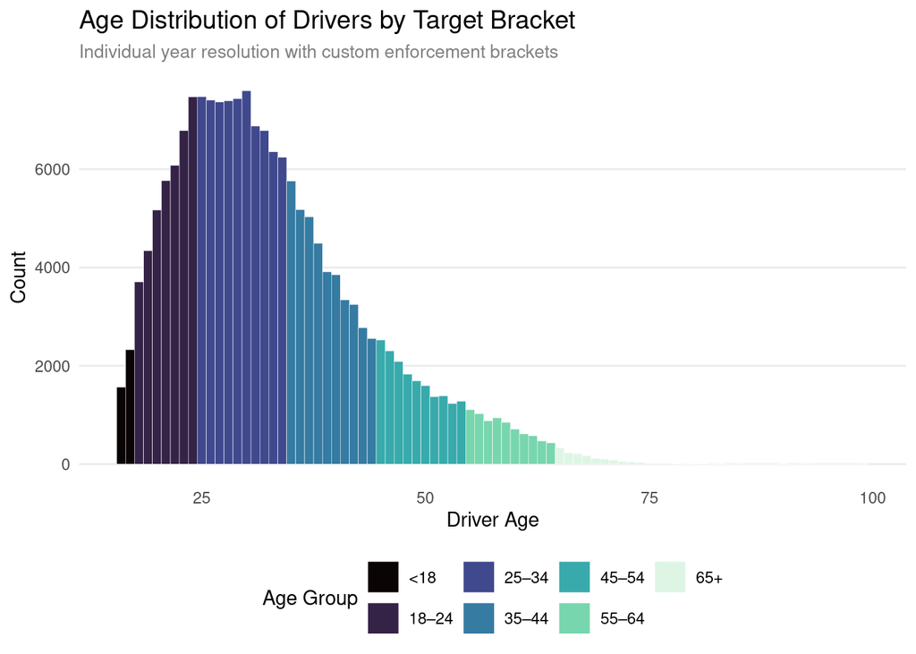

```r
# 1. Create the brackets and clean the data
age_data <- vehstops %>%
  filter(!is.na(age), age >= 0, age < 100) %>%
  mutate(
    age_group = case_when(
      age < 18 ~ "<18",
      age >= 18 & age <= 24 ~ "18–24",
      age >= 25 & age <= 34 ~ "25–34",
      age >= 35 & age <= 44 ~ "35–44",
      age >= 45 & age <= 54 ~ "45–54",
      age >= 55 & age <= 64 ~ "55–64",
      age >= 65 ~ "65+"
    ),
    # Ensure the order is kept in the plot
    age_group = factor(age_group, levels = c("<18", "18–24", "25–34", "35–44", "45–54", "55–64", "65+"))
  )

# 2. Plotting
ggplot(age_data, aes(x = age, fill = age_group)) +
  # binwidth = 1 keeps the individual resolution
  geom_histogram(binwidth = 1, color = "white", linewidth = 0.1) +
  # Adding clear color differentiation for the brackets
  scale_fill_viridis_d(option = "mako") +
  theme_minimal() +
   theme(
    panel.grid.major.x = element_blank(),
    panel.grid.minor = element_blank(),
    plot.title = element_text(size = 14),
    plot.subtitle = element_text(color = "grey50", size = 10),
    strip.text = element_text(size = 11)
  ) +
  labs(
    title = "Age Distribution of Drivers by Target Bracket",
    subtitle = "Individual year resolution with custom enforcement brackets",
    x = "Driver Age",
    y = "Count",
    fill = "Age Group"
  ) +
  theme(legend.position = "bottom") +
  guides(fill = guide_legend(nrow = 2))
```

What can we say?

```r
vehstops <- vehstops %>%
  filter(age < 76)
```

From now on we will consider drivers of age in the range 16-75.

### Reported Sex

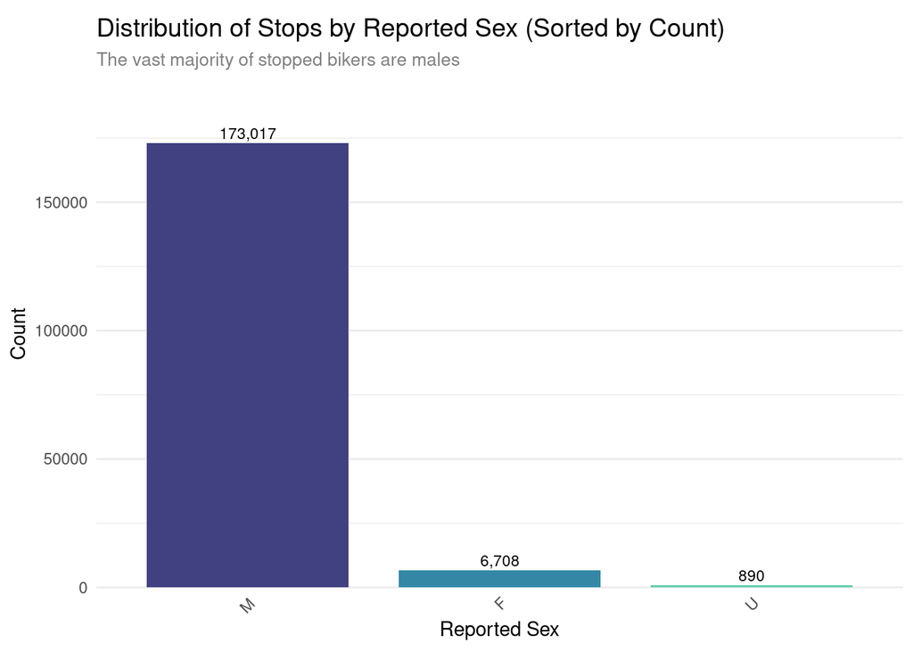

```r
plot_univariate_cat(
  DF = vehstops,
  FEATURE = sex,
  X_LABEL = "Reported Sex",
  TITLE = "Distribution of Stops by Reported Sex (Sorted by Count)",
  SUBTITLE = "The vast majority of stopped bikers are males",
  order_by = "freq"
)
```

What can we say?

- Key finding: The data exhibits extreme class imbalance. “Male” (M) drivers represent the overwhelming majority of enforcement stops (approximately 96%), while “Female” (F) and “Unknown” (U) represent a negligible fraction of the total volume.
- Interpretation: This is not a data quality issue—it is an operational reflection of the driver demographic being targeted Because the skew is so profound, “Sex” will inevitably become a high-importance feature in any model you train. The model will essentially learn that “Being Male = High Probability of Stop” simply because that is the status quo in the dataset.
- Comment: You must be cautious here. If you use this feature as-is, you risk creating a model that is “biased by design.” Because the dataset is so skewed, the model could achieve very high mathematical accuracy by simply predicting “Male” for every single case. You are currently looking at exposure (who is on the road), not necessarily propensity (who is most likely to be stopped).
- Proposed Action: Run a correlation matrix to see if sex is highly correlated with other variables. When splitting your data for training/testing, ensure you use stratified sampling (preserving the M/F/U ratio in both sets). If you don’t, your test set might end up with no “Female” or “Unknown” records, making it impossible to evaluate your model’s performance on those sub-groups

### Reported Ethnicity

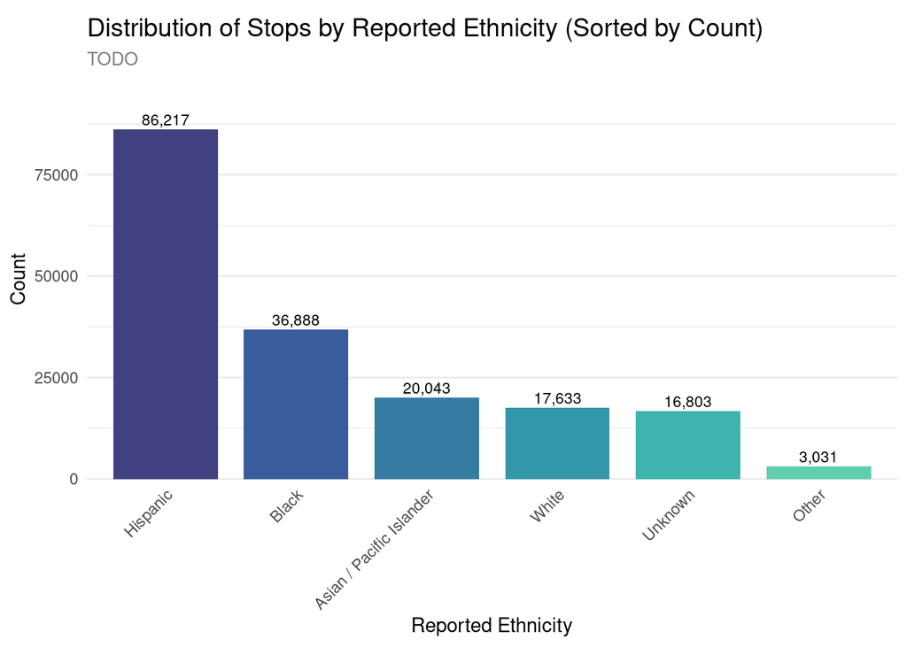

```r
plot_univariate_cat(
  DF = vehstops,
  FEATURE = ethnicity,
  X_LABEL = "Reported Ethnicity",
  TITLE = "Distribution of Stops by Reported Ethnicity (Sorted by Count)",
  SUBTITLE = "TODO",
  order_by = "freq"
)
```

What can we say?

- Key finding: The distribution is heavily skewed, with “Hispanic” drivers accounting for the plurality of stops (over 86,000), far outpacing other groups. The “Unknown” category is also statistically significant (~16,800), mirroring the data quality patterns you observed with age.
- Interpretation: This data does not reflect a balanced, random sampling of the driving population; it reflects an enforcement density. The high concentration of specific demographics suggests that either the geographic areas targeted for enforcement have high Hispanic populations, or the specific types of vehicles/courier work being monitored are disproportionately staffed by this demographic.
- Comment: Because the distribution is so imbalanced, a machine learning model will aggressively use “ethnicity” to predict stops. It will effectively “learn” that a stop is more likely for one group over another based on the historical pattern.
- Proposed Action: Before including ethnicity in your regression, perform a correlation check against boro. When training your model, ensure your training and testing splits are stratified by ethnicity.

# Bivariate EDA

We have structured this analysis into three distinct phases. First, we employ a Cramer’s V association matrix to assess categorical relationships; this is preferred over a standard Chi-squared test as it provides a normalized measure of strength better suited to our large data volume.

To complement this, we utilize visual trend analysis to detect potential collinearity. By plotting arrest rates over time and faceting by variables such as “Area,” we can observe whether patterns “drift” in unison. Parallel movement across these facets strongly suggests collinearity.

Finally, once we transition to the modeling phase, we will implement formal post-hoc diagnostics, such as Generalized Variance Inflation Factors (GVIF), to rigorously validate our model’s integrity.